# Education's Correlation to Quality of Life

### Data 601 Final Project Fall 2024

By: Jackson Meier, Max Paterson, Noah Seminoff, Weiwei Wang

## Introduction

This report is on the topic of world education, and what factors positively or negatively impact a countries outcome in the realm of education. Our project aims to explore the inputs and outputs of education to achieve a better understanding as to what factors contribute to a postitive educational experience, as well as what a successful education system looks like. By understanding these factors, we can also look at different societal outcomes to learn the importance of a strong education and how they relate to positive societal outcomes.

We chose this dataset and the corresponding guiding questions to not only better understand what a positive education can do for countries, but also to gain appreciation for the high-quality and easily accessible education we have access to hear in Canada. We are fortunate enough to be exposed to a well-structured education system from a very young age, with seemingly infinite educational opportunities even after high school. It is very easy to take our education system for granted, and through our exploration of our dataset, we hope to gain a better appreciation and understand as to how fortunate we really are to have the opportunities we do in Canada.

## Dataset and Guiding Questions

#### Dataset

The dataset that we are going to be working with is an education statistics dataset published by the World Bank Group. This dataset was first published in 2010 and updated most recently in 2024. The dataset contains 3665 metrics across 242 regions. This dataset was aggregated by the World Bank Group from many different data sources, combining them into one large dataset. This is how it has such a wide variety of metrics measured across so many different regions.

The dataset contains data for each year from 1970 to 2017, and then every 5 years from 2020 to 2100, as it includes projections for some of the metrics as well. These years are listed as columns, and each rows represents a combination of which metric and what region. For example, row 360,500 is "Gross enrolment ratio, primary to tertiary, male (%), in Ghana", and across this row for each year column is either the value of the metric for that year, or NaN if no data was collected was collected. The original dataset has a total of 69 columns and 886,931 rows.

The license to use this dataset is Creative Commons Attribution 4.0, which means that it is free to use and adapt as long as the correct citation is present.

#### Interesting Aspects

The things that interested us in this dataset are actually the same things which hinder us while using this dataset. We were very interested in this dataset because of its wide range of metrics as well as years that it contains. Thousands of metrics and over 5 million total data points is an amazing dataset to look into, leveraging the power of python. However, this does cause us problems as well.

Another interesting aspect of this dataset is how the metrics are set up. Instead of having a column for each metric, where you could just compare two columns to each other when wanting to look for a correlation. There is actually just one column that lists each metric. This makes the analysis part of our project much more difficult because instead of just being able to look at two different columns, we have to create two new sub data frames that only contain the certain metric that we are looking at. On top of that, we then need to ensure that we can match up each country and year with its corresponding values for both of the metrics. There may be some years and countries who only have data for one of the metrics and not the other. If this were in a data frame where the metrics are the columns we would be able to just drop any rows that contain and Na's and analyse the two columns data. Because of the fact that we have over 3,000 metrics, it is not suitable to change the metrics to be columns and thus this is a problem that is going to have to be dealt with.

#### Guiding Questions

Our guiding questions have evolved a bit from our original project proposal as we gained more insight into our data and really analysed what relationships we are looking for.

Our four guiding questions are

1. How greatly does the pupil to teacher ratio affect the success rates of students? （Max)
2. How does an increase in access to the internet affect the success of students? (Jackson)
3. Does the number of students going on to higher education indicate a better schooling system and higher GDP? (Noah)
4. What are the gender differences and trends in education? (Weiwei)

Originally, for our first guiding question we stated that we were looking at how the pupil to teacher ratio affected the quality of education as well as the success rate of students. However, as we delved into the metrics that we though were most relevant, we realized that what we were really measuring was how it affected the success rates of students.

We had the same change for our second guiding questions, changing it from the quality of schooling to the success rates of students.

Although our guiding questions are centered around looking for correlation between metrics, we will also spend some time doing general analysis of our variables so that we get a better understanding of the variables that we are working with.

## Analysis

In order to analyze the data, we first need to import and clean the data.

```python
import numpy as np
import pandas as pd
import matplotlib.pyplot as plt
```

Originally, the data was presented as a zip file containing multiple CSV files. It has since been updated to only be a single CSV, which can be accessed from here (https://datacatalog.worldbank.org/search/dataset/0038480).

We first import the data from a set of 3 csv files. The first containing a multitude of values for metrics, by both region and year. The other two are legends that give more information about each metric and each country. We also take each of these and extract the rows of interest, as well as reindexing to make our lives easier later.

```python
# load datasets
edstats_csv = pd.read_csv("EdStatsData.csv") # country/indicator/year
edseries_csv = pd.read_csv("EdStatsSeries.csv") # series code to indicator name
edcountry_csv = pd.read_csv("EdStatsCountry.csv") # country code to country name
```

```python
# list of indicators (by short code, general topic, and long name)
edseries = edseries_csv[["Series Code", "Topic", "Indicator Name"]].copy(deep=True).set_index("Series Code")

# list of countries (by short code, long name, and some extra info about each)
edcountry = edcountry_csv[["Country Code", "Short Name","Region","Income Group"]].copy(deep=True).set_index("Country Code")

# data by country code,indicator code,year Code")
edstats = edstats_csv.copy(deep=True)
```

We then melt the year columns down to a single column which we can use to filter later.

```python
edstats = pd.melt(edstats,
                  id_vars=['Country Name', 'Country Code', 'Indicator Name', 'Indicator Code'], # columns to keep
                  value_vars=edstats.columns.values[4:-1], # list of year columns
                  value_name="Rating") # column name for the value of the indicators
```

```python
edstats.info()
```

```
<class 'pandas.core.frame.DataFrame'>
RangeIndex: 57650450 entries, 0 to 57650449
Data columns (total 6 columns):
 #   Column          Dtype
---  ------          -----
 0   Country Name    object
 1   Country Code    object
 2   Indicator Name  object
 3   Indicator Code  object
 4   variable        object
 5   Rating          float64
dtypes: float64(1), object(5)
memory usage: 2.6+ GB
```

From the info, we can see there is now over 57 million rows, and it is taking up 2.6 GB of memory. To help with this, we can drop the rows without any data in the `Rating` column. i.e., the metric + country + year combinations that do not have any data.

```python
edstats.dropna(subset=["Rating"], inplace=True)
```

```python
edstats.info()
```

```
<class 'pandas.core.frame.DataFrame'>
Index: 5082201 entries, 4 to 57650441
Data columns (total 6 columns):
 #   Column          Dtype
---  ------          -----
 0   Country Name    object
 1   Country Code    object
 2   Indicator Name  object
 3   Indicator Code  object
 4   variable        object
 5   Rating          float64
dtypes: float64(1), object(5)
memory usage: 271.4+ MB
```

This drops us from 57 million entries, down to about 5 million. We also need to clean up a little, renaming columns and dropping redundant information.

```python
# rename column containing years to be more descriptive
edstats = edstats.rename(columns={'variable':'Year'})

# retype year as unsigned int16 to save memory
edstats["Year"] = edstats['Year'].astype("uint16")

# remove excess information (represented in own dataframes already)
edstats = edstats.drop(["Country Name", "Indicator Name"], axis=1)

# set index of data based on indicator code
edstats = edstats.set_index("Indicator Code")
edstats = edstats.sort_index()
```

```python
edstats.info()
```

```
<class 'pandas.core.frame.DataFrame'>
Index: 5082201 entries, BAR.NOED.1519.FE.ZS to XGDP.56.FSGOV.FDINSTADM.FFD
Data columns (total 3 columns):
 #   Column        Dtype
---  ------        -----
 0   Country Code  object
 1   Year          uint16
 2   Rating        float64
dtypes: float64(1), object(1), uint16(1)
memory usage: 126.0+ MB
```

Our large dataset is now using significantly less memory. We can do something similar to the other two "legend" datasets, drooping the rows that don't have any corresponding data in the main dataset.

```python
hasdatamask = edseries.index.intersection(edstats.index)
edseries = edseries.loc[hasdatamask]
```

We also define a few functions to help parse data more easily:

```python
## functions to parse the indicators and the country names ##

def listtopics():
    """ list all series topics
    """
    return list(edseries.Topic.unique())

def get_indicators_by_topic(topic):
    """ display indicators under the give `topic` name.
    """
    return list(edseries[edseries.Topic == topic]["Indicator Name"].values)

def get_indicators_containing(contains):
    """ display indicator names containing the word `contains`
    """
    mask = [(contains in str) for str in edseries["Indicator Name"].values]
    return edseries[mask]["Indicator Name"].values

def get_series_code(indicator_name):
    """ return the series code based on given indicator name
    """
    return edseries[ edseries["Indicator Name"] == indicator_name ].index.values[0]

def get_country_code_by_name(countryname):
    """ pass in "Canada" to get "CAN", etc
    """
    return edcountry[edcountry["Short Name"] == countryname].index[0]

def get_country_name_by_code(countrycode):
    """ pass in "CAN" to get "Canada"
    """
    return edcountry.loc[countrycode]["Short Name"]
```

```python
## functions to get a list of topics, sorted by how many rows of data
def get_indicators_by_topic_sorted(topic, cutoff=1, howmany=-1):
    """ print out all indicators under a given topic (with more than cutoff rows),
    and how many rows of data they have. prints out `howmany` results (or all, if howmany<=0) """
    printcount = 0 # increment counter

    # indicator code by occurances (most data to least data)
    howmuchdata = edstats.groupby(["Indicator Code"])["Rating"].count().sort_values(ascending=False)

    # table header
    print("Count  | Metric \n-------|---------")

    # show all metrics by name, sorted by size of data:
    for code in howmuchdata.index.values: # loop through metrics
        datacount = howmuchdata.loc[code] # current count
        if datacount >= cutoff: # if count is greater than cutoff
            try: # avoid errors
                if edseries.loc[code]["Topic"] == topic: # check topic matches
                    if howmany <= 0:
                        # if everythings good, print it out
                        print(f"{datacount:6d} | {edseries.loc[code, 'Indicator Name']}")
                    elif printcount < howmany:
                        print(f"{datacount:6d} | {edseries.loc[code, 'Indicator Name']}")
                        printcount += 1
            except:
                pass

def get_indicators_containing_sorted(keyword, cutoff=1, howmany=-1):
    """ print out all indicators containing a given keyword (with more than cutoff rows),
    and how many rows of data they have. prints out `howmany` results (or all, if howmany<=0)"""
    printcount = 0 # increment counter

    # indicator code by occurances (most data to least data)
    howmuchdata = edstats.groupby(["Indicator Code"])["Rating"].count().sort_values(ascending=False)

    # table header
    print("Count  | Metric \n-------|---------")

    # show all metrics by name, sorted by size of data:
    for code in howmuchdata.index.values: # loop through metrics
        datacount = howmuchdata.loc[code] # current count
        if datacount >= cutoff: # if count is greater than cutoff
            try: # avoid errors
                if  keyword.lower() in edseries.loc[code]["Indicator Name"].lower(): # check keyword matches
                    if howmany <= 0:
                        # if everythings good, print it out
                        print(f"{datacount:6d} | {edseries.loc[code, 'Indicator Name']}")
                    elif printcount < howmany:
                        print(f"{datacount:6d} | {edseries.loc[code, 'Indicator Name']}")
                        printcount += 1
            except:
                pass
```

```python
## functions to get a subset of the data ##

def get_data_by_code(code, yearstart=1970, yearend=2100):
    """ get dataframe by indicator code
    """
    yearmask = (edstats.Year >= yearstart) & (edstats.Year <= yearend)
    return edstats[yearmask].loc[code]

def get_data_by_name(name, yearstart=1970, yearend=2100):
    """ get dataframe by indicator name
    """
    return get_data_by_code(get_series_code(name), yearstart=yearstart, yearend=yearend)
```

### Guiding Question 1:

**How greatly does the pupil to teach ratio affect both the quality of education provided, and the success rate of students?**

To answer this question we are going to be looking at the main variable of pupil to teacher ratio. This is the main variable of interest because we want to see how changes in this may have affects on other aspects of the quality of schooling such as the success rate of students and how many of them continue on to higher education.

We have to keep in mind that it is difficult to prove more than correlation, especially when there are lots of other factors that could be affecting these variables, such as GDP. Because of this we will always take a look at the GDP correlation to these metrics as well to ensure that we are providing a well-rounded view of our data and factors that may affect it.

#### Exploratory Analysis of Metrics

First off, we are going to create new sub datasets for all the different metrics that we plan on looking at to answer our guiding question. But we shall start with some exploratory analysis of them.

```python
puptoteach = get_data_by_name("Pupil-teacher ratio in primary education (headcount basis)", 1970, 2015)
repeaters = get_data_by_name("Percentage of repeaters in primary education, all grades, both sexes (%)", 1970, 2015)
grossenrolment = get_data_by_name("Gross enrolment ratio, upper secondary, both sexes (%)", yearstart=2000, yearend=2015)
gdp = get_data_by_name("GDP per capita (current US$)", 1970, 2015)
```

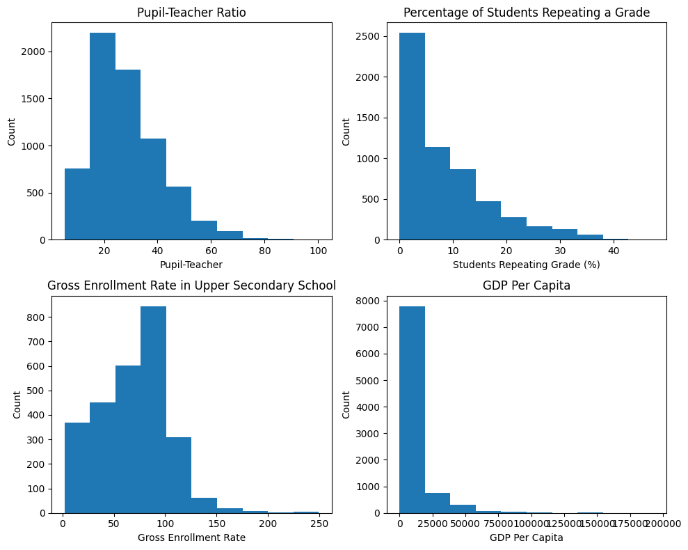

```python
fig, axis = plt.subplots(2,2,figsize=(10,8))

axis[0,0].hist(puptoteach["Rating"])
axis[0,1].hist(repeaters["Rating"])
axis[1,0].hist(grossenrolment["Rating"])
axis[1,1].hist(gdp["Rating"])

axis[0,0].set_title('Pupil-Teacher Ratio')
axis[0,1].set_title('Percentage of Students Repeating a Grade')
axis[1,0].set_title('Gross Enrollment Rate in Upper Secondary School')
axis[1,1].set_title('GDP Per Capita')

axis[0,0].set_xlabel("Pupil-Teacher")
axis[0,0].set_ylabel("Count")

axis[0,1].set_xlabel("Students Repeating Grade (%)")
axis[0,1].set_ylabel("Count")

axis[1,0].set_xlabel("Gross Enrollment Rate")
axis[1,0].set_ylabel("Count")

axis[1,1].set_xlabel("GDP Per Capita")
axis[1,1].set_ylabel("Count")

plt.tight_layout()
plt.show()
```

From this we are able to see the overall distribution of all of these metrics in the entire dataset. Now we want to look at the trend throughout the years for this data, we are going to do this by grouping the data by year and looking at the overall mean of the dataset for each year and each metric.

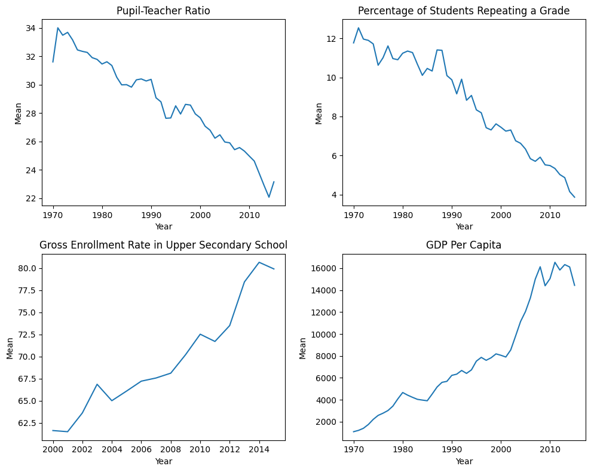

```python
fig, axis = plt.subplots(2,2,figsize=(10,8))

puptoteachgroup = puptoteach[["Year","Rating"]].reset_index()
puptoteachgroup = puptoteachgroup.drop(["Indicator Code"], axis = 1)
puptoteachgroup = puptoteach.groupby(["Year"])['Rating'].mean().reset_index()

repeatersgroup = repeaters[["Year","Rating"]].reset_index()
repeatersgroup = repeatersgroup.drop(["Indicator Code"], axis = 1)
repeatersgroup = repeatersgroup.groupby(["Year"])['Rating'].mean().reset_index()

grossenrolementgroup = grossenrolment[["Year","Rating"]].reset_index()
grossenrolementgroup = grossenrolementgroup.drop(["Indicator Code"], axis = 1)
grossenrolementgroup = grossenrolementgroup.groupby(["Year"])['Rating'].mean().reset_index()

gdpgroup = gdp[["Year","Rating"]].reset_index()
gdpgroup = gdpgroup.drop(["Indicator Code"], axis = 1)
gdpgroup = gdpgroup.groupby(["Year"])['Rating'].mean().reset_index()

axis[0,0].plot(puptoteachgroup["Year"], puptoteachgroup["Rating"])
axis[0,1].plot(repeatersgroup["Year"], repeatersgroup["Rating"])
axis[1,0].plot(grossenrolementgroup["Year"], grossenrolementgroup["Rating"])
axis[1,1].plot(gdpgroup["Year"], gdpgroup["Rating"])

axis[0,0].set_title('Pupil-Teacher Ratio')
axis[0,1].set_title('Percentage of Students Repeating a Grade')
axis[1,0].set_title('Gross Enrollment Rate in Upper Secondary School')
axis[1,1].set_title('GDP Per Capita')

axis[0,0].set_xlabel("Year")
axis[0,0].set_ylabel("Mean")

axis[0,1].set_xlabel("Year")
axis[0,1].set_ylabel("Mean")

axis[1,0].set_xlabel("Year")
axis[1,0].set_ylabel("Mean")

axis[1,1].set_xlabel("Year")
axis[1,1].set_ylabel("Mean")

plt.tight_layout()
plt.show()
```

Overall, we see that all the metrics that we are looking at have been improving. The pupil-teacher ratio has been going down, the percentage of students repeating a grade has been going down and the gross enrollment and GDP per capita have both been going up. Note, that due to inconsistencies in the gross enrollment in upper secondary ratio, we have only started plotting it at the year 2000.

This is great news for the education system, but can we see if these metrics are correlated to each other?

To do this we are going to have to combine our datasets and only have the resulting rows where data is present for both of the metrics, for a certain year and region. We can merge the first two data frames by common country and year, and then merge this one with GDP to add the third one.

The first analysis we are going to look at is the correlation between pupil-teacher ratio and the percent of students repeating a grade.

#### Pupil to Teacher Ratio

```python
#Restating all the sub datasets to look at 2005 to 2015
puptoteach = get_data_by_name("Pupil-teacher ratio in primary education (headcount basis)", 2005, 2015)
repeaters = get_data_by_name("Percentage of repeaters in primary education, all grades, both sexes (%)", 2005, 2015)
grossenrolment = get_data_by_name("Gross enrolment ratio, upper secondary, both sexes (%)", yearstart=2005, yearend=2015)
gdp = get_data_by_name("GDP per capita (current US$)", 2005, 2015)

puptorepeat = pd.merge(puptoteach, repeaters, on=["Country Code","Year"], how='inner',suffixes=('_ptot','_repeat'))
puptorepeatgdp = pd.merge(puptorepeat, gdp, on=["Country Code","Year"], how='inner')

grosstopupil = pd.merge(puptoteach, grossenrolment, on=["Country Code","Year"], how='inner', suffixes=('_ptot','_gross'))
grosstopupilgdp = pd.merge(grosstopupil, gdp, on=["Country Code","Year"], how='inner')
```

One thing to note is that the suffixes only get applied to column names when there are duplicate columns names. During our second merge there are not going to be any duplicate column names and thus we have not supplied any suffixes.

We now have the sufficient data needed to make a scatter plot of the pupil-teacher ratio versus the percentage of repeaters in a grade. We are going to start by looking at some of the years by themselves to get a picture of whether or not the relationship may be changing.

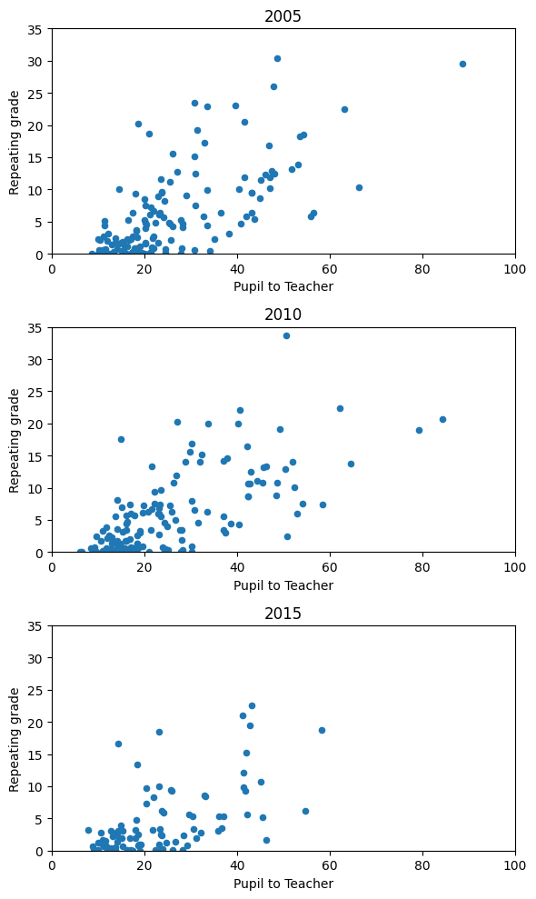

```python
fig, axis = plt.subplots(3,1, figsize=(6,10))

axis[0].scatter(x=puptorepeatgdp[puptorepeatgdp['Year'] == 2005]['Rating_ptot'],y=puptorepeatgdp[puptorepeatgdp['Year'] == 2005]['Rating_repeat'], s=20)
axis[0].set_ylabel('Repeating grade')
axis[0].set_xlabel('Pupil to Teacher')
axis[0].set_title("2005")
axis[0].set_xlim(0,100)
axis[0].set_ylim(0,35)

axis[1].scatter(x=puptorepeatgdp[puptorepeatgdp['Year'] == 2010]['Rating_ptot'],y=puptorepeatgdp[puptorepeatgdp['Year'] == 2010]['Rating_repeat'], s=20)
axis[1].set_ylabel('Repeating grade')
axis[1].set_xlabel('Pupil to Teacher')
axis[1].set_title("2010")
axis[1].set_xlim(0,100)
axis[1].set_ylim(0,35)

axis[2].scatter(x=puptorepeatgdp[puptorepeatgdp['Year'] == 2015]['Rating_ptot'],y=puptorepeatgdp[puptorepeatgdp['Year'] == 2015]['Rating_repeat'], s=20)
axis[2].set_ylabel('Repeating grade')
axis[2].set_xlabel('Pupil to Teacher')
axis[2].set_title("2015")
axis[2].set_xlim(0,100)
axis[2].set_ylim(0,35)

plt.tight_layout()
plt.show()
```

As we had seen before, while looking into these different metrics we see that over the course of the ten years that we are looking at, the pupil to teacher ratio is going down. We also see the percentage of people repeating a grade also goes down in general.

Seeing this decrease in the amount of students repeating a grade for 2015 really makes me interested in whether or not internet access may have an effect on this as well?

Next we will create one large graph that contains all the years from 2005 to 2015 combined in it to see if we see an overall trend for the data. After seeing the previous graph it is reasonable to expect to see a similar relationship where the increase in pupil-teacher ratio increases the percentage of students repeating a grade.

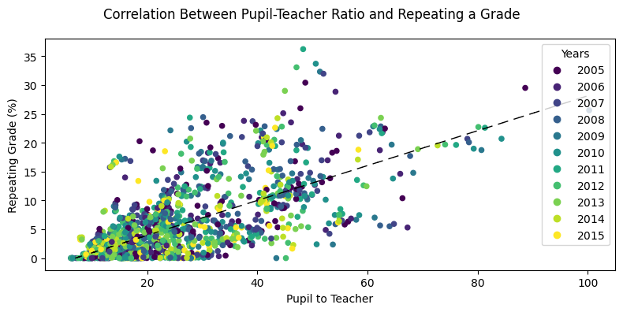

```
The slope of our linear regression line is  0.3023044850257184
```

```python
fig, axis = plt.subplots(figsize=(8,4))

scatter = axis.scatter(x=puptorepeatgdp['Rating_ptot'],y=puptorepeatgdp['Rating_repeat'],c=puptorepeatgdp['Year'], s=20)

axis.set_ylabel('Repeating Grade (%)')
axis.set_xlabel('Pupil to Teacher')
fig.suptitle("Correlation Between Pupil-Teacher Ratio and Repeating a Grade")

axis.legend(*scatter.legend_elements(), loc="upper right", title="Years")

m, b = np.polyfit(puptorepeatgdp['Rating_ptot'], puptorepeatgdp['Rating_repeat'], 1)
plt.plot(puptorepeatgdp['Rating_ptot'], m*puptorepeatgdp['Rating_ptot']+b, linestyle=(0,(5,10)), linewidth=1, color='black')

plt.tight_layout()
plt.show()
print("The slope of our linear regression line is ",m)
```

```python
# and the correlation coeff,
print("Correlation Coefficient between pupil to teacher ratio and repeating a grade is: ", np.corrcoef(puptorepeatgdp['Rating_ptot'], puptorepeatgdp['Rating_repeat'])[0,1])
```

```
Correlation Coefficient between pupil to teacher ratio and repeating a grade is:  0.6761196003058959
```

We can see from this graph and the correlation coefficient that there seems to be a relationship between repeating a grade and the pupil-teacher ratio. But as we stated at the start of this section, one thing we need to keep an eye on as well is the GDP to see if that is possibly also a factor. To do this we will plot the GDP per capita as the size of the markers, so that we can visually see which areas tend to have a larger GDP.

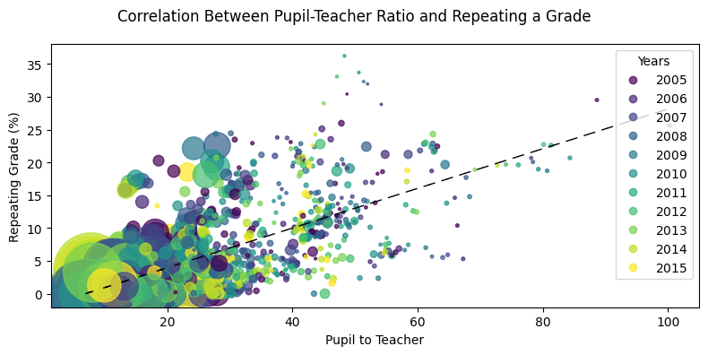

```python
fig, axis = plt.subplots(figsize=(8,4))

scatter = axis.scatter(x=puptorepeatgdp['Rating_ptot'],y=puptorepeatgdp['Rating_repeat'],c=puptorepeatgdp['Year'], s=puptorepeatgdp['Rating']/50, alpha=0.7)

axis.set_ylabel('Repeating Grade (%)')
axis.set_xlabel('Pupil to Teacher')
fig.suptitle("Correlation Between Pupil-Teacher Ratio and Repeating a Grade")

axis.legend(*scatter.legend_elements(), loc="upper right", title="Years")

m, b = np.polyfit(puptorepeatgdp['Rating_ptot'], puptorepeatgdp['Rating_repeat'], 1)
plt.plot(puptorepeatgdp['Rating_ptot'], m*puptorepeatgdp['Rating_ptot']+b, linestyle=(0,(5,10)), linewidth=1, color='black')

plt.tight_layout()
plt.show()
```

Unsurprisingly, we do see that the countries with the higher GDP's tend to have smaller pupil to teacher ratios as well as less students repeating a grade. However, this does not mean that it pupil to teacher is less significant. It is very possible that the reason that these countries have a smaller percentage of students repeating a grade is entirely based on the pupil to teacher ratio, and the pupil to teacher ratio is often reflected by the GDP per capita.

But this is not always the case and we can look at some specific cases to illustrate this.

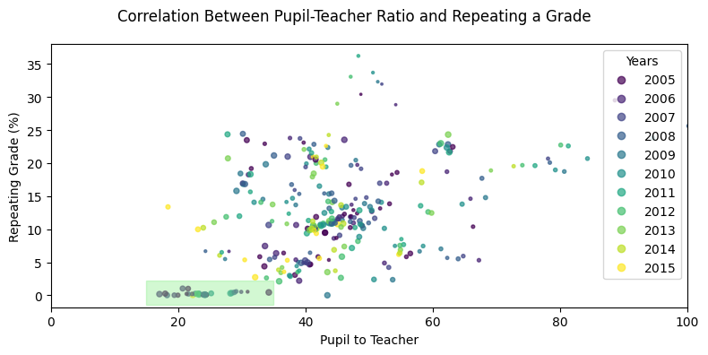

```python
fig, axis = plt.subplots(figsize=(8,4))

scatter = axis.scatter(x=puptorepeatgdp[puptorepeatgdp["Rating"] < 1000]['Rating_ptot'],
                       y=puptorepeatgdp[puptorepeatgdp["Rating"] < 1000]['Rating_repeat'],
                       c=puptorepeatgdp[puptorepeatgdp["Rating"] < 1000]['Year'],
                       s=puptorepeatgdp[puptorepeatgdp["Rating"] < 1000]['Rating']/50, alpha=0.7)

axis.set_ylabel('Repeating Grade (%)')
axis.set_xlabel('Pupil to Teacher')
axis.set_xlim(0,100)

fig.suptitle("Correlation Between Pupil-Teacher Ratio and Repeating a Grade")

axis.legend(*scatter.legend_elements(), loc="upper right", title="Years")

#Adding a rectangle to highlight the data
axis.axvspan(xmin=15,xmax=35,ymin=0.01,ymax=0.1,color='lightgreen', alpha=0.4)

plt.tight_layout()
plt.show()
```

Here we see an example of some regions who have a quite small GDP per capita, but also have decent pupil to teacher ratios and very few students repeating a grade. This shows that it is not always dependent on the GDP, although it is often the case that the higher GDP countries fair better when looking at these metrics. These examples show us that it is possible, independent of GDP, that a lower pupil to teacher ratio can help the success rates of students.

Lastly, for this metric we are going to use numpys correlation coefficient function to numerically determine the correlation between these two metrics.

```python
print("Correlation matrix between pupil-teacher ratio and percent of students repeating a grade is \n",
      np.corrcoef(puptorepeatgdp["Rating_ptot"], puptorepeatgdp["Rating_repeat"])[0,1],"\n")

print("Correlation matrix between pupil-teacher ratio and the GDP per capita is \n",
      np.corrcoef(puptorepeatgdp["Rating_ptot"], puptorepeatgdp["Rating"])[0,1],"\n")

print("Correlation matrix between the percent of students repeating a grade and the GDP per capita is \n",
      np.corrcoef(puptorepeatgdp["Rating_repeat"], puptorepeatgdp["Rating"])[0,1])
```

```
Correlation matrix between pupil-teacher ratio and percent of students repeating a grade is
 0.6761196003058959

Correlation matrix between pupil-teacher ratio and the GDP per capita is
 -0.4839692937101911

Correlation matrix between the percent of students repeating a grade and the GDP per capita is
 -0.34481785006139226
```

We see that the correlation coefficient between our two main metrics of interest, pupil-teacher ratio and the percent of students repeating a grade is actually the highest out of all the correlation coefficients that we calculated at a strong 0.676. This further helps illustrate that although GDP per capita does have an effect, it does not have the strongest correlation with our metrics of interest.

Additionally, to further test our hypothesis of whether or not pupil-teacher ratio affects the success of students we are also going to look at the gross enrollment rate in upper secondary.

#### Gross Enrollment Rate in Upper Secondary

Gross enrolment rate, as defined by the World Bank Group, can actually be above 100%. This is because they take the number of children who are in the defined age for a certain grade, and then use that as the denominator and the numerator as the amount of children in that grade. However, you can have cases were a grade may have more students in it, that do not actually fit into the age range, and thus the gross enrollment rate could be over 100%.

When the metric says 'upper secondary' which is defined as schooling for ages of around 16-19. For Canada for example we would call this high school.

Similar to the last metric, we are going to start by looking at how it has changed over the years.

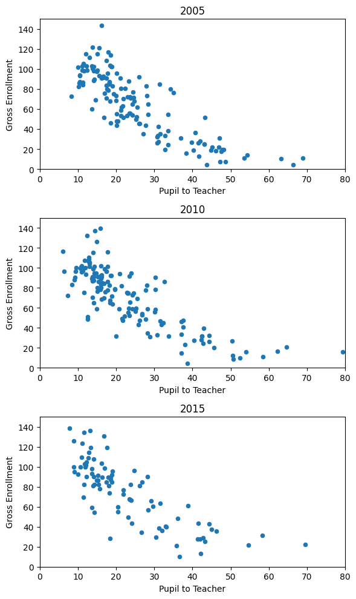

```python
fig, axis = plt.subplots(3,1, figsize=(6,10))

axis[0].scatter(x=grosstopupilgdp[grosstopupilgdp['Year'] == 2005]['Rating_ptot'],y=grosstopupilgdp[grosstopupilgdp['Year'] == 2005]['Rating_gross'], s=20)
axis[0].set_ylabel('Gross Enrollment')
axis[0].set_xlabel('Pupil to Teacher')
axis[0].set_title("2005")
axis[0].set_xlim(0,80)
axis[0].set_ylim(0,150)

axis[1].scatter(x=grosstopupilgdp[grosstopupilgdp['Year'] == 2010]['Rating_ptot'],y=grosstopupilgdp[grosstopupilgdp['Year'] == 2010]['Rating_gross'], s=20)
axis[1].set_ylabel('Gross Enrollment')
axis[1].set_xlabel('Pupil to Teacher')
axis[1].set_title("2010")
axis[1].set_xlim(0,80)
axis[1].set_ylim(0,150)

axis[2].scatter(x=grosstopupilgdp[grosstopupilgdp['Year'] == 2015]['Rating_ptot'],y=grosstopupilgdp[grosstopupilgdp['Year'] == 2015]['Rating_gross'], s=20)
axis[2].set_ylabel('Gross Enrollment')
axis[2].set_xlabel('Pupil to Teacher')
axis[2].set_title("2015")
axis[2].set_xlim(0,80)
axis[2].set_ylim(0,150)

plt.tight_layout()
plt.show()
```

Looking at the different years, we do not actually see much of a difference between the graphs. The relationship between pupil to teacher ratio and the gross enrollment ratio in upper secondary seems to stay quite consistent.

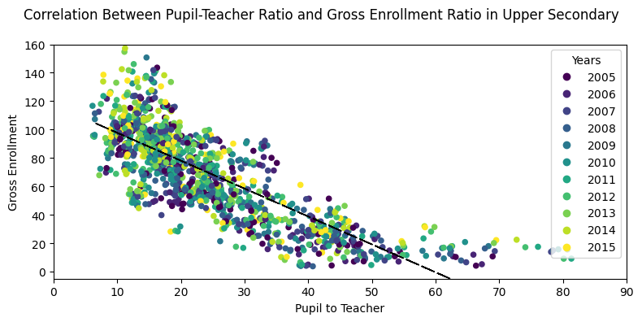

```
The slope of our linear regression line is  -1.9648141021872
```

```python
fig, axis = plt.subplots(figsize=(8,4))

scatter = axis.scatter(x=grosstopupilgdp['Rating_ptot'],y=grosstopupilgdp['Rating_gross'],c=grosstopupilgdp['Year'], s=20)

axis.set_ylabel('Gross Enrollment')
axis.set_xlabel('Pupil to Teacher')
fig.suptitle("Correlation Between Pupil-Teacher Ratio and Gross Enrollment Ratio in Upper Secondary")

axis.legend(*scatter.legend_elements(), loc="upper right", title="Years")
axis.set_xlim(0,90)
axis.set_ylim(-5,160)

m, b = np.polyfit(grosstopupilgdp['Rating_ptot'], grosstopupilgdp['Rating_gross'], 1)
plt.plot(grosstopupilgdp['Rating_ptot'], m*grosstopupilgdp['Rating_ptot']+b, linestyle=(0,(5,10)), linewidth=1, color='black')

plt.tight_layout()
plt.show()
print("The slope of our linear regression line is ",m)
```

```python
# and the correlation coeff,
print("Correlation Coefficient between pupil to teacher ratio and repeating a grade is: ", np.corrcoef(grosstopupilgdp['Rating_ptot'], grosstopupilgdp['Rating_gross'])[0,1])
```

```
Correlation Coefficient between pupil to teacher ratio and repeating a grade is:  -0.8118415554207228
```

Once again, we seem to see a correlation between these two metrics. We are once again going to take a look into what the GDP looks like on this graph as well.

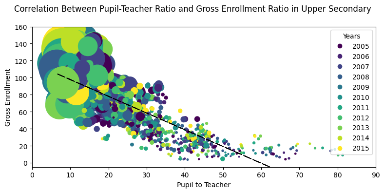

```python
fig, axis = plt.subplots(figsize=(8,4))

scatter = axis.scatter(x=grosstopupilgdp['Rating_ptot'],y=grosstopupilgdp['Rating_gross'],c=grosstopupilgdp['Year'], s=grosstopupilgdp['Rating']/50)

axis.set_ylabel('Gross Enrollment')
axis.set_xlabel('Pupil to Teacher')
fig.suptitle("Correlation Between Pupil-Teacher Ratio and Gross Enrollment Ratio in Upper Secondary")

axis.legend(*scatter.legend_elements(), loc="upper right", title="Years")
axis.set_xlim(0,90)
axis.set_ylim(-5,160)

m, b = np.polyfit(grosstopupilgdp['Rating_ptot'], grosstopupilgdp['Rating_gross'], 1)
plt.plot(grosstopupilgdp['Rating_ptot'], m*grosstopupilgdp['Rating_ptot']+b, linestyle=(0,(5,10)), linewidth=1, color='black')

plt.tight_layout()
plt.show()
```

We see that the countries with a high GDP per capita tend to have a small pupil to teacher ratio and a high percentage of gross enrollment in upper secondary. This, as we have stated before makes sense because of course the higher GDP per capita, the better pupil to teacher ratio they will be able to attain. Again, we want to see if there are some regions that buck the trend and show that even with a small GDP, a lower pupil to teacher ratio positively affects the gross enrolment in upper secondary.

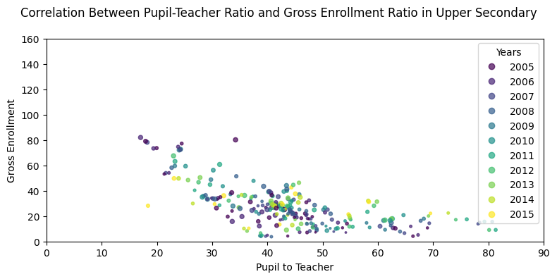

```python
fig, axis = plt.subplots(figsize=(8,4))

scatter = axis.scatter(x=grosstopupilgdp[grosstopupilgdp["Rating"] < 1000]['Rating_ptot'],
                       y=grosstopupilgdp[grosstopupilgdp["Rating"] < 1000]['Rating_gross'],
                       c=grosstopupilgdp[grosstopupilgdp["Rating"] < 1000]['Year'],
                       s=grosstopupilgdp[grosstopupilgdp["Rating"] < 1000]['Rating']/50, alpha=0.7)

axis.set_ylabel('Gross Enrollment')
axis.set_xlabel('Pupil to Teacher')
axis.set_xlim(0,90)
axis.set_ylim(0,160)

fig.suptitle("Correlation Between Pupil-Teacher Ratio and Gross Enrollment Ratio in Upper Secondary")

axis.legend(*scatter.legend_elements(), loc="upper right", title="Years")

# #Adding a rectangle to highlight the data
# axis.axvspan(xmin=15,xmax=35,ymin=0.01,ymax=0.1,color='lightgreen', alpha=0.4)

plt.tight_layout()
plt.show()
```

Even among the countries that have a small GDP per capita, we see that if they decrease the pupil to teacher ratio the gross enrollment rate in upper secondary could go up. Once again, we see that it is not strictly GDP which is making these affects. Even countries with a small GDP per capita can have good pupil to teacher ratios and thus a higher gross enrollment rate as compared to their similar counterparts with a high pupil to teacher ratio.

Now to check the correlation coefficients.

```python
print("Correlation matrix between pupil-teacher ratio and gross enrollment in upper secondary \n",
      np.corrcoef(grosstopupilgdp["Rating_ptot"], grosstopupilgdp["Rating_gross"])[0,1],"\n")

print("Correlation matrix between pupil-teacher ratio and the GDP per capita is \n",
      np.corrcoef(grosstopupilgdp["Rating_ptot"], grosstopupilgdp["Rating"])[0,1],"\n")

print("Correlation matrix between the gross enrollment in upper secondary and the GDP per capita is \n",
      np.corrcoef(grosstopupilgdp["Rating_gross"], grosstopupilgdp["Rating"])[0,1])
```

```
Correlation matrix between pupil-teacher ratio and gross enrollment in upper secondary
 -0.8118415554207228

Correlation matrix between pupil-teacher ratio and the GDP per capita is
 -0.5018367889000986

Correlation matrix between the gross enrollment in upper secondary and the GDP per capita is
 0.5654395045659367
```

We see that the correlation coefficient between the pupil to teacher ratio and the gross enrollment in upper secondary has the strongest relationship at -0.811, which is considered a very strong correlation coefficient.

Overall, after using the percent of students repeating a grade as well as the gross enrollment in upper secondary as two metrics to look at the affect that the pupil to teacher ratio had on them we can see that the correlation is quite significant. The pupil to teacher ratio was highly correlated to both of these metrics and bearing in mind that it is quite hard to find actual causation, we can definitely say there was significant correlation. On top of the work that we did with looking at just the regions that have a small GDP per capita, it seems that there is some sort of causation between the pupil to teacher ratio and the success rates of the students.

This is not the most outlandish claim as when there are less students to a class, the students get more one on one time with the teacher which would make sense if it was related to their success.

### Guiding Question 2:

**How does an increase in access to the internet affect the success of students?**

To answer this question, we are going to be looking at the variable of internet users per 100 people, and compare it to the percentage of repeaters in primary education.

Lets first create some new dataframes with the two factors we will be looking at.

```python
internetusers = get_data_by_name("Internet users (per 100 people)")
repeaters = get_data_by_name("Percentage of repeaters in primary education, all grades, both sexes (%)")
```

We will start with some exploratory analysis of these two datasets before we compare them.

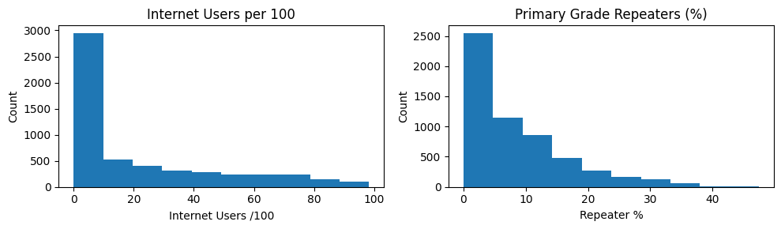

```python
fig, axis =plt.subplots(1,2,figsize = (10,3))

axis[0].hist(internetusers["Rating"])
axis[1].hist(repeaters["Rating"])

axis[0].set_title("Internet Users per 100")
axis[1].set_title("Primary Grade Repeaters (%)")

axis[0].set_xlabel("Internet Users /100")
axis[0].set_ylabel("Count")

axis[1].set_xlabel("Repeater %")
axis[1].set_ylabel("Count")
plt.tight_layout()
```

At first glance, these graphs do look somewhat similar. Lets now compare them over time, by grouping them by year to see if there is a pattern.

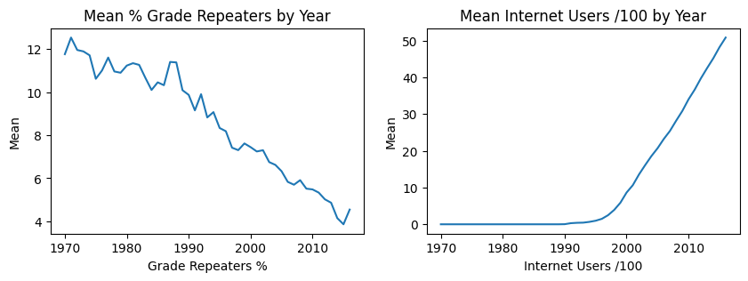

```python
fig,axis = plt.subplots(1,2,figsize = (10,3))

internetby_year = internetusers[["Year","Rating"]].reset_index()
internetby_year = internetby_year.drop(["Indicator Code"],axis = 1)
internetby_year = internetusers.groupby(["Year"])["Rating"].mean().reset_index()

repeaterby_year = repeaters[["Year","Rating"]].reset_index()
repeaterby_year = repeaterby_year.drop(["Indicator Code"],axis = 1)
repeaterby_year = repeaters.groupby(["Year"])["Rating"].mean().reset_index()

axis[0].plot(repeaterby_year["Year"],repeaterby_year["Rating"])
axis[1].plot(internetby_year["Year"],internetby_year["Rating"])

axis[0].set_title("Mean % Grade Repeaters by Year")
axis[1].set_title("Mean Internet Users /100 by Year")

axis[0].set_xlabel("Grade Repeaters %")
axis[0].set_ylabel("Mean")

axis[1].set_xlabel("Internet Users /100")
axis[1].set_ylabel("Mean")
```

We can now see some distinct differences between the two groups. These trends should not come as a surprise. Over the years, less and less children have been seen failing a grade, whether that is due to increasing quality in education, or societal norms, regardless, more kids pass and this number seems to be consistently rising. For our internet users, this chart should also be fairly intuitive. No one had internet access before the internet was invented, but since then, the number has climbed and climbed.

Now, we have looked at one analysis of these subsets where they look very similar, and one showing distinct differences between the two. It's time to answer the question of whether or not these two variables are correlated.

```python
#Merging the  dataset to compare
repeaterstointernet = pd.merge(repeaters,internetusers, on=["Country Code","Year"], how = "inner",suffixes =('_repeat','_internet') )
```

Now that we have created our merged dataset, lets take a look at the relationship between these two variables in some different years. As we saw in our previous charts, internet usage has climbed drastically since the early 2000's. We can take a look to see how this relationship has changed along with the worlds acceptance and embrace of the internet.

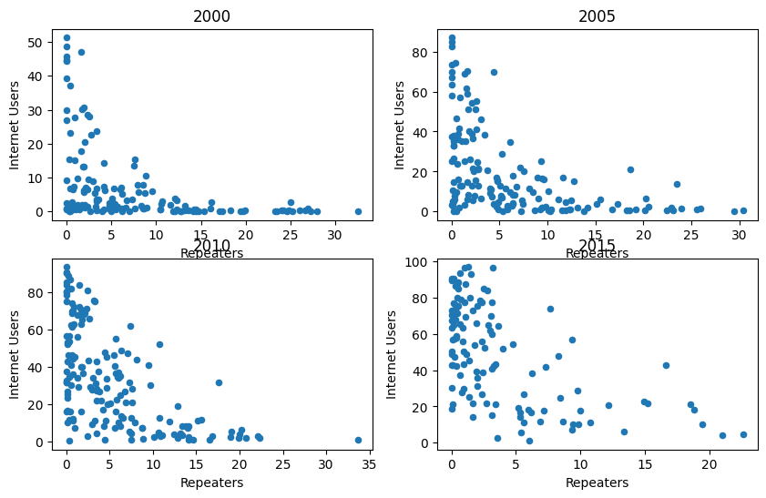

```python
fig, axis = plt.subplots(2,2, figsize = (10,6))

axis[0,0].scatter(x =repeaterstointernet[repeaterstointernet['Year'] == 2000]['Rating_repeat'],y = repeaterstointernet[repeaterstointernet['Year'] == 2000]['Rating_internet'],s=20)
axis[0,0].set_xlabel('Repeaters')
axis[0,0].set_ylabel('Internet Users')
axis[0,0].set_title('2000')

axis[0,1].scatter(x =repeaterstointernet[repeaterstointernet['Year'] == 2005]['Rating_repeat'],y = repeaterstointernet[repeaterstointernet['Year'] == 2005]['Rating_internet'],s=20)
axis[0,1].set_xlabel('Repeaters')
axis[0,1].set_ylabel('Internet Users')
axis[0,1].set_title('2005')

axis[1,0].scatter(x =repeaterstointernet[repeaterstointernet['Year'] == 2010]['Rating_repeat'],y = repeaterstointernet[repeaterstointernet['Year'] == 2010]['Rating_internet'],s=20)
axis[1,0].set_xlabel('Repeaters')
axis[1,0].set_ylabel('Internet Users')
axis[1,0].set_title('2010')

axis[1,1].scatter(x =repeaterstointernet[repeaterstointernet['Year'] == 2015]['Rating_repeat'],y = repeaterstointernet[repeaterstointernet['Year'] == 2015]['Rating_internet'],s=20)
axis[1,1].set_xlabel('Repeaters')
axis[1,1].set_ylabel('Internet Users')
axis[1,1].set_title('2015')
```

Once again, these graphs seem to show some sort of correlation between an increasing amount of internet users and a lower amount of grade repeaters. As we advance every 5 years, there become many more internet users, and the number of repeaters seem to move somewhat closer to zero. Our large outliers of repeaters always seems to be close to the zero amount for internet users.

We will now calculate and plot the linear regression comparing grade repeaters to internet users per 100.

```
The slope of our linear regression model is -1.5284117578598462
```

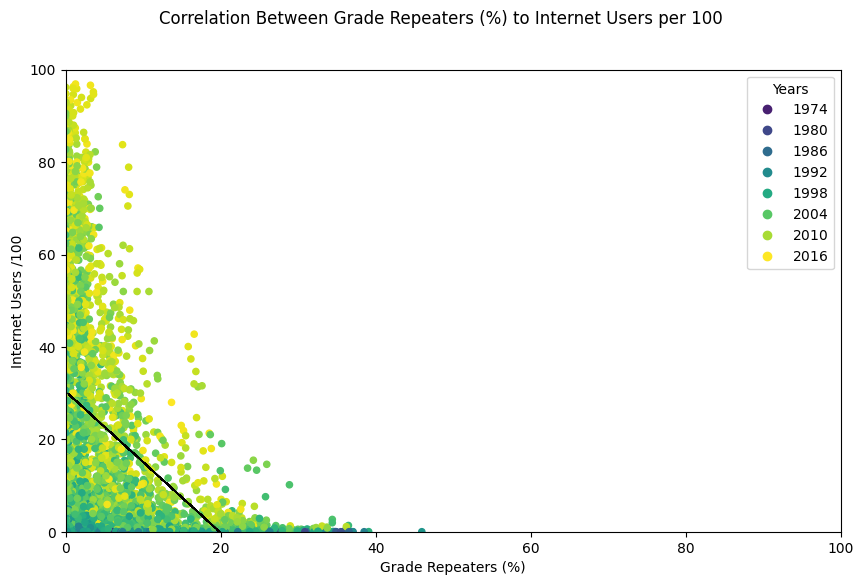

```python
fig, axis = plt.subplots(figsize = (10,6))
scatter = axis.scatter(x = repeaterstointernet['Rating_repeat'], y = repeaterstointernet['Rating_internet'],c = repeaterstointernet['Year'],s = 20)
axis.set_ylabel('Internet Users /100')
axis.set_xlabel('Grade Repeaters (%)')
fig.suptitle("Correlation Between Grade Repeaters (%) to Internet Users per 100")
axis.legend(*scatter.legend_elements(), loc = 'upper right', title = "Years")
axis.set_xlim(0,100)
axis.set_ylim(0,100)

m,b = np.polyfit(repeaterstointernet['Rating_repeat'],repeaterstointernet['Rating_internet'], 1)
plt.plot(repeaterstointernet['Rating_repeat'], m*repeaterstointernet['Rating_repeat'] + b, linestyle = (1,(8,10)), linewidth = 1, color = 'black')
plt.tight_layout

print("The slope of our linear regression model is",m)
```

```python
print('Our correlation coefficient between grade repeaters as a percentage and internet users per 100 is ',
      np.corrcoef(repeaterstointernet['Rating_repeat'],repeaterstointernet['Rating_internet'])[0,1],"\n")
```

```
Our correlation coefficient between grade repeaters as a percentage and internet users per 100 is  -0.43612985336684995
```

As we can see here, we have a low to moderate correlation between the two variables at play. This number makes sense, as you would expect the quality of education to be higher in areas with access to the internet, however the weak correlation is likely explained by the other factors at play. As we know, internet access is a privilege and a tool, but not a necessity for an education.

Overall, our analysis in this guiding question shows that as we give more people access to the internet, the odds of having to repeat a grade drops. Although we see a moderate negative correlation between the two variables, it is important to note that this dataset goes back before the internet was widely accessible to the general public. Since the internet has become a staple in most countries, the percent of grade repeaters drops significantly.

### Guiding Question 3:

**Does the number of students going on to higher education indicate a better schooling system and higher GDP?**

First, we need to find which metrics to look at.

```python
listtopics()
```

```
['Attainment',
 'Education Equality',
 'Infrastructure: Communications',
 'Learning Outcomes',
 'Economic Policy & Debt: National accounts: US$ at current prices: Aggregate indicators',
 'Economic Policy & Debt: National accounts: US$ at constant 2010 prices: Aggregate indicators',
 'Economic Policy & Debt: Purchasing power parity',
 'Economic Policy & Debt: National accounts: Atlas GNI & GNI per capita',
 'Teachers',
 'Education Management Information Systems (SABER)',
 'Early Child Development (SABER)',
 'Engaging the Private Sector (SABER)',
 'School Health and School Feeding (SABER)',
 'School Autonomy and Accountability (SABER)',
 'School Finance (SABER)',
 'Student Assessment (SABER)',
 'Teachers (SABER)',
 'Tertiary Education (SABER)',
 'Workforce Development (SABER)',
 'Literacy',
 'Background',
 'Primary',
 'Secondary',
 'Tertiary',
 'Early Childhood Education',
 'Pre-Primary',
 'Expenditures',
 'Health: Risk factors',
 'Health: Mortality',
 'Social Protection & Labor: Labor force structure',
 'Laber',
 'Social Protection & Labor: Unemployment',
 'Health: Population: Structure',
 'Population',
 'Health: Population: Dynamics',
 'EMIS',
 'Post-Secondary/Non-Tertiary']
```

Higher education indicators are likely listed under "Tertiary" (University, etc) or "Post-Secondary/Non-Tertiary" (vocational schooling). Quality of Schooling may be related to "Learning Outcomes". GDP we can get by keyword.

```python
get_indicators_by_topic_sorted("Tertiary", howmany=25)
```

```
Count  | Metric
-------|---------
  6606 | Enrolment in tertiary education, all programmes, both sexes (number)
  6391 | Gross enrolment ratio, tertiary, both sexes (%)
  6254 | School life expectancy, tertiary, both sexes (years)
  5715 | Enrolment in tertiary education, all programmes, female (number)
  5676 | School life expectancy, primary to tertiary, both sexes (years)
  5631 | Percentage of students in tertiary education who are female (%)
  5516 | Gross enrolment ratio, tertiary, male (%)
  5516 | Gross enrolment ratio, tertiary, female (%)
  5505 | Gross enrolment ratio, tertiary, gender parity index (GPI)
  5359 | School life expectancy, tertiary, female (years)
  5359 | School life expectancy, tertiary, gender parity index (GPI)
  5359 | School life expectancy, tertiary, male (years)
  5143 | Enrolment in tertiary education per 100,000 inhabitants, both sexes
  4971 | Gross enrolment ratio, primary to tertiary, both sexes (%)
  4720 | School life expectancy, primary to tertiary, female (years)
  4720 | School life expectancy, primary to tertiary, male (years)
  4259 | Enrolment in tertiary education per 100,000 inhabitants, male
  4257 | Enrolment in tertiary education per 100,000 inhabitants, female
  3541 | Graduates from tertiary education, both sexes (number)
  3290 | Gross outbound enrolment ratio, all regions, both sexes (%)
  2866 | Graduates from tertiary education, female (number)
  2836 | Percentage of graduates from tertiary education who are female (%)
  2407 | Outbound mobility ratio, all regions, both sexes (%)
  1985 | Percentage of all students in tertiary education enrolled in ISCED 5, both sexes (%)
  1960 | Percentage of students in tertiary ISCED 5 programmes who are female (%)
```

```python
get_indicators_by_topic_sorted("Post-Secondary/Non-Tertiary")
```

```
Count  | Metric
-------|---------
  1210 | School life expectancy, post-secondary non-tertiary, both sexes (years)
  1188 | Gross enrolment ratio, post-secondary non-tertiary, both sexes (%)
  1161 | School life expectancy, post-secondary non-tertiary, gender parity index (GPI)
  1161 | School life expectancy, post-secondary non-tertiary, male (years)
  1161 | School life expectancy, post-secondary non-tertiary, female (years)
  1142 | Gross enrolment ratio, post-secondary non-tertiary, male (%)
  1138 | Gross enrolment ratio, post-secondary non-tertiary, gender parity index (GPI)
  1138 | Gross enrolment ratio, post-secondary non-tertiary, female (%)
  1059 | Percentage of students in post-secondary non-tertiary education enrolled in vocational programmes, both sexes (%)
  1026 | Percentage of students in post-secondary non-tertiary vocational education who are female (%)
  1023 | Percentage of male students in post-secondary non-tertiary education enrolled in vocational programmes, male (%)
  1020 | Percentage of female students in post-secondary non-tertiary education enrolled in vocational programmes, female (%)
   984 | Enrolment in post-secondary non-tertiary education, private institutions, both sexes (number)
   981 | Percentage of enrolment in post-secondary non-tertiary education in private institutions (%)
   528 | Percentage of students in post-secondary non-tertiary education enrolled in general programmes, both sexes (%)
   527 | Percentage of students in post-secondary non-tertiary general education who are female (%)
   513 | Percentage of male students in post-secondary non-tertiary education enrolled in general programmes, male (%)
   511 | Percentage of female students in post-secondary non-tertiary education enrolled in general programmes, female (%)
   288 | Enrolment in post-secondary non-tertiary education, private institutions, female (number)
```

```python
get_indicators_by_topic_sorted("Learning Outcomes", howmany=20)
```

```
Count  | Metric
-------|---------
   344 | PISA: Mean performance on the mathematics scale. Female
   344 | PISA: Mean performance on the mathematics scale. Male
   344 | PISA: Mean performance on the science scale. Female
   344 | PISA: Mean performance on the science scale
   344 | PISA: Mean performance on the science scale. Male
   343 | PISA: Mean performance on the reading scale
   343 | PISA: Mean performance on the reading scale. Male
   343 | PISA: Mean performance on the reading scale. Female
   341 | PISA: 15-year-olds by reading proficiency level (%). Level 1A
   341 | PISA: 15-year-olds by reading proficiency level (%). Level 3
   341 | PISA: Distribution of Science Scores: 90th Percentile Score
   341 | PISA: Distribution of Science Scores: 10th Percentile Score
   341 | PISA: 15-year-olds by reading proficiency level (%). Level 6
   341 | PISA: Male 15-year-olds by reading proficiency level (%). Level 2
   341 | PISA: Distribution of Reading Scores: 50th Percentile Score
   341 | PISA: Distribution of Reading Scores: 25th Percentile Score
   341 | PISA: Female 15-year-olds by reading proficiency level (%). Level 6
   341 | PISA: Distribution of Mathematics Scores: 90th Percentile Score
   341 | PISA: Male 15-year-olds by reading proficiency level (%). Level 1A
   341 | PISA: Distribution of Reading Scores: 10th Percentile Score
```

```python
get_indicators_containing_sorted("GDP")
```

```
Count  | Metric
-------|---------
  9199 | GDP (current US$)
  9196 | GDP per capita (current US$)
  8883 | GDP (constant 2010 US$)
  8880 | GDP per capita (constant 2010 US$)
  5615 | GDP, PPP (constant 2011 international $)
  5612 | GDP per capita, PPP (constant 2011 international $)
  5610 | GDP, PPP (current international $)
  5607 | GDP per capita, PPP (current international $)
  3538 | Government expenditure on education as % of GDP (%)
  1496 | Government expenditure per primary student as % of GDP per capita (%)
  1408 | Government expenditure on tertiary education as % of GDP (%)
  1367 | Government expenditure per tertiary student as % of GDP per capita (%)
  1350 | Government expenditure on primary education as % of GDP (%)
  1340 | Government expenditure on secondary education as % of GDP (%)
  1333 | Government expenditure per secondary student as % of GDP per capita (%)
  1234 | Government expenditure on pre-primary education as % of GDP (%)
  1201 | Government expenditure in secondary institutions education as % of GDP (%)
  1195 | Government expenditure in tertiary institutions as % of GDP (%)
   911 | Government expenditure per lower secondary student as % of GDP per capita (%)
   897 | Government expenditure per upper secondary student as % of GDP per capita (%)
   742 | Government expenditure on post-secondary non-tertiary education as % of GDP (%)
   613 | Government expenditure in post-secondary non-tertiary institutions as % of GDP (%)
   504 | Government expenditure per post-secondary non-tertiary student as % of GDP per capita (%)
    85 | Government expenditure on secondary and post-secondary non-tertiary vocational education as % of GDP (%)
```

From the above, some metrics of interest may be:

- Enrolment in tertiary education, all programmes, both sexes (number)
- Enrolment in tertiary education per 100,000 inhabitants, both sexes
- Gross enrolment ratio, tertiary, both sexes (%)
- Gross enrolment ratio, post-secondary non-tertiary, both sexes (%)
- PISA: Mean performance on the reading scale
- GDP (current US$)
- Government expenditure on education as % of GDP (%)
- Government expenditure on tertiary education as % of GDP (%)

Since Enrolment by total number may be influenced by the size of a country, we can skip this first one.

Enrolment per 100,000 inhabitants is out of the total population, while gross enrolment ratio (GER) is the ratio of the number students enrolled in tertiary education expressed as a percentage of population who have graduated *secondary* education within the last 5 years. This number can be higher than 100% if a large amount of enrollment comes from students who enroll earlier or later than this 5 year period. Since we also have GER for non-tertirary schooling which may be interesting, it may be a better comparison to use GER for both cases.

The reading scale performance can be used as a reflection of the quality of education received. There are also similar scores for mathematics and science if needed.

Finally, we have GDP adjusted for inflation and converted to USD, as well as spending on education (overall) and tertiary education, both as a percentage of the GDP.

```python
q3_ger_ter = get_data_by_name("Gross enrolment ratio, tertiary, both sexes (%)")
q3_ger_nonter = get_data_by_name("Gross enrolment ratio, post-secondary non-tertiary, both sexes (%)")
q3_reading = get_data_by_name("PISA: Mean performance on the reading scale")
q3_gdp = get_data_by_name("GDP (current US$)")
q3_gdp_ed = get_data_by_name("Government expenditure on education as % of GDP (%)")
q3_gdp_ed = q3_gdp_ed[q3_gdp_ed["Rating"] <= 100] # ignore outliers that spend more than 100% of GDP on education
q3_gdp_ter = get_data_by_name("Government expenditure on tertiary education as % of GDP (%)")
```

We can look at the distributions of these metrics:

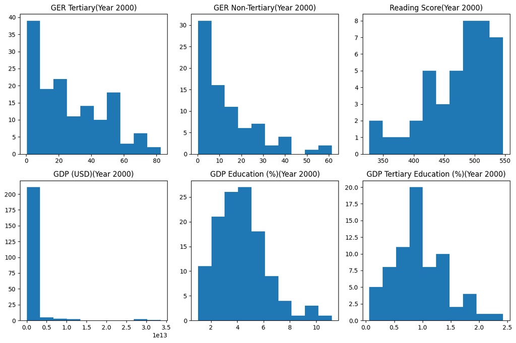

```python
## plot histograms.

# list of dataframes to plot
q3dfs_all = [q3_ger_ter, q3_ger_nonter, q3_reading,q3_gdp, q3_gdp_ed, q3_gdp_ter]
q3dfs_all_names = ["GER Tertiary", "GER Non-Tertiary", "Reading Score", "GDP (USD)", "GDP Education (%)", "GDP Tertiary Education (%)"]

# set up figure and axes' objects
fig, axs = plt.subplots(2,3, figsize=(12,8))

# iterate over (2,3) array of axes objects, but flatten to (1,6)
# so we can use the index to get the dataframe from the list of dataframes
for i,ax in enumerate(axs.flat):
    # plot hist, set title
    ax.hist(q3dfs_all[i]["Rating"][q3dfs_all[i]["Year"] == 2000])
    ax.set_title(q3dfs_all_names[i] + "(Year 2000)")

plt.tight_layout()
plt.show()
```

We can also compare how these values change over time on average:

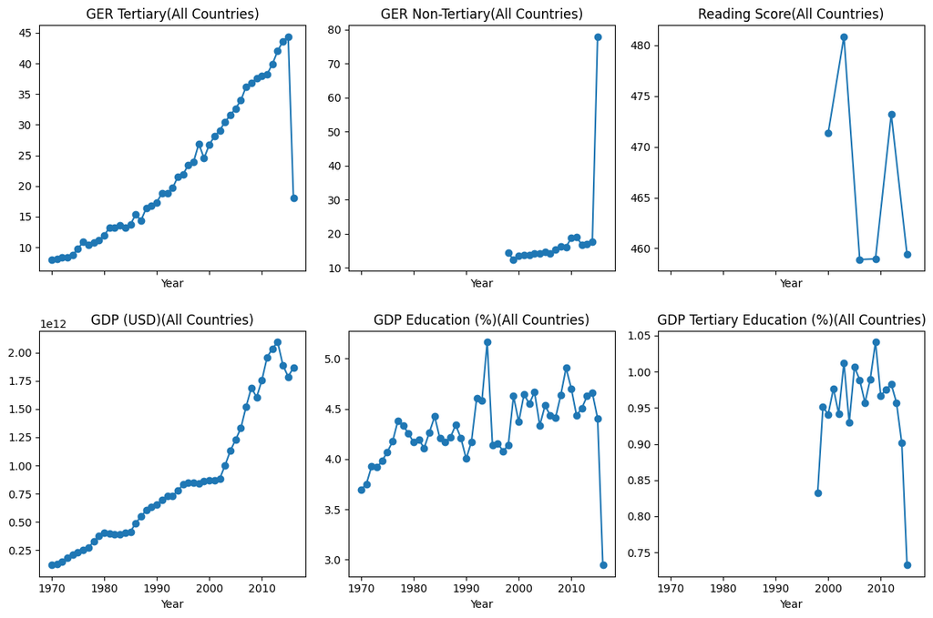

```python
fig, axs = plt.subplots(2,3, figsize=(12,8), sharex=True)

for i,ax in enumerate(axs.flat):
    q3group_current = q3dfs_all[i].groupby("Year")["Rating"].mean().reset_index()
    ax.plot(q3group_current.Year, q3group_current.Rating, marker="o")
    ax.set_title(q3dfs_all_names[i] + "(All Countries)")
    ax.set_xlabel("Year")

plt.tight_layout()
plt.show()
```

We can see over time, the enrollment rate in tertiary education seems to increase over time, from less than 10% in the 70's to almost 45% in the last few years. The drop-off at the end appears to be due to a single datapoint (perhaps not all countries have reported GER yet for the latest year, so the average is not fully representitive). Similarly, GER for non-tertiary post-secondary (vocational) seems to increase over time (with an errant datapoint at the end again). Reading score do not seem to have enough data to pick out any sort of trend (since there are only 6 years with data, perhaps different countries are represented in some data points and not others). GDP increases over time as we would expect. Percentage spent on education seems to have increased slightly since the 70's, hovering around 4-5%. Spending on tertiary education seems to hover around 1%, with a recent dropoff that is probably something similar to the errant data we saw in the GER plots.

To plot relationships between variables, we can pick a few of the metrics to combine (Not too many, since there is likely less overlap the more we pick). Here we pick tertiary GER, reading performance, and total GDP.

```python
def merge_dataframes(dflist, colnames, on=["Country Code", "Year"], how="inner"):
    """ merge an arbitrary length list of dataframes `dflist` by the `on` columns.
    rename the merged columns based on the list `colnames`, which should be the
    same length as `dflist`. returns a single dataframe
    """
    from functools import reduce
    mergeddf = reduce(lambda left,right: pd.merge(left,right,on=on, how=how), dflist)
    mergeddf.columns = on + colnames
    return mergeddf
```

```python
q3df_list = [q3_ger_ter, q3_reading, q3_gdp]
q3df_titles = ["GER_Tertiary", "Reading_Performance", "GDP"]

q3df = merge_dataframes(q3df_list, q3df_titles)
q3df.head(5)
```

|  | Country Code | Year | GER_Tertiary | Reading_Performance | GDP |
| --- | --- | --- | --- | --- | --- |
| 0 | ARG | 2006 | 66.831100 | 373.723772 | 2.325573e+11 |
| 1 | JPN | 2012 | 61.458172 | 538.051485 | 6.203213e+12 |
| 2 | SWE | 2009 | 71.451881 | 497.449424 | 4.296570e+11 |
| 3 | THA | 2006 | 44.244598 | 416.751765 | 2.217585e+11 |
| 4 | KOR | 2015 | 93.179138 | 517.436700 | 1.382764e+12 |

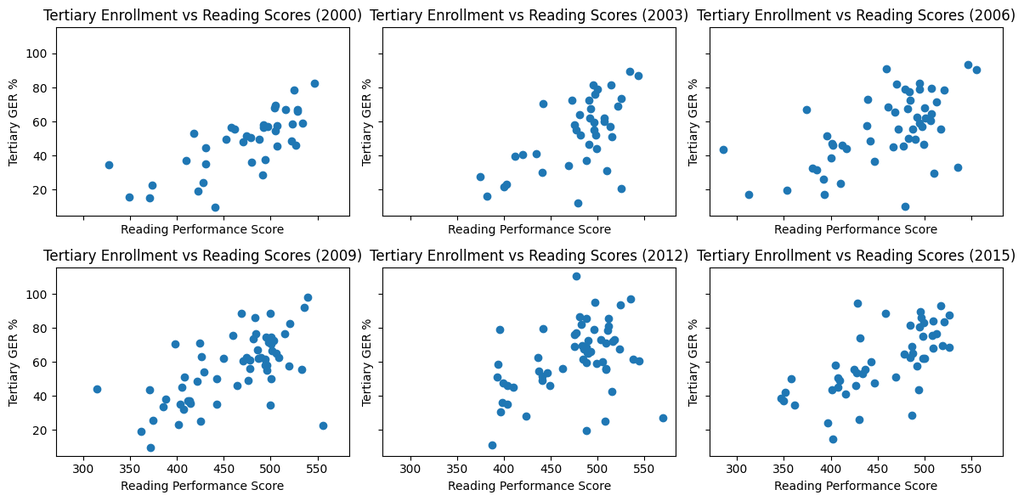

```python
# plot scatter of GER to reading performance by country, for specific years
fig, axs = plt.subplots(2,3, figsize=(2*6,3*2), sharex=True, sharey=True)

# what years to plot
q3_ratio_years = [2000, 2003, 2006, 2009, 2012, 2015]

# loop over axes, plot each thing
for i,ax in enumerate(axs.flat):
    # scatter for this specific year
    q3_current = q3df[q3df.Year == q3_ratio_years[i]]
    ax.scatter(x = q3_current["Reading_Performance"],
              y= q3_current["GER_Tertiary"],
              #s= q3_current["GDP"]/10**10, alpha=0.7,
              marker="o")
    ax.set_title("Tertiary Enrollment vs Reading Scores (" + str(q3_ratio_years[i]) + ")")
    ax.set_ylabel("Tertiary GER %")
    ax.set_xlabel("Reading Performance Score")

plt.tight_layout()
plt.show()
```

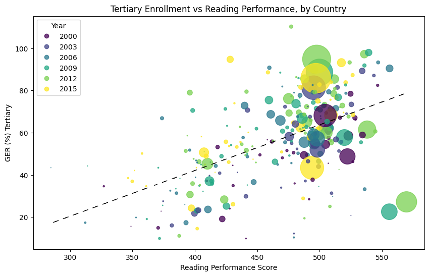

```python
# plot all years on same plot
fig, ax = plt.subplots(figsize=(10,6))

scatter = ax.scatter(x = q3df.Reading_Performance,
                     y = q3df.GER_Tertiary,
                     c = q3df.Year,
                     s = q3df.GDP * (10**-10),
                     alpha=0.75)

ax.set_xlabel("Reading Performance Score")
ax.set_ylabel("GER (%) Tertiary")
ax.set_title("Tertiary Enrollment vs Reading Performance, by Country")

# best fit line
m, b = np.polyfit(q3df["Reading_Performance"], q3df["GER_Tertiary"], 1)
ax.plot(q3df["Reading_Performance"], m*q3df["Reading_Performance"]+b,
        linestyle=(0,(5,10)), linewidth=1, color="black")

ax.legend(*scatter.legend_elements(), loc="upper left", title="Year")
plt.show()
```

```python
# and the correlation coeff,
print("Correlation Coefficient between Reading Score and GER Tertiary is: ", np.corrcoef(q3df["Reading_Performance"], q3df["GER_Tertiary"])[0,1])
```

```
Correlation Coefficient between Reading Score and GER Tertiary is:  0.5532160140389192
```

We can see that in a given year, there seems to be a rough linear relationship (But with a correlation coefficnet of 0.55, it's not very significant), whereby higher reading scores seem to result in roughly higher enrollment in tertiary schooling. However, the reading comprehension test is done at 15 years old, and these same students are not moving on to tertiary education until a few years later at 18 or onwards. We can thus look at the reading scores in a given year, against the GER a few years later

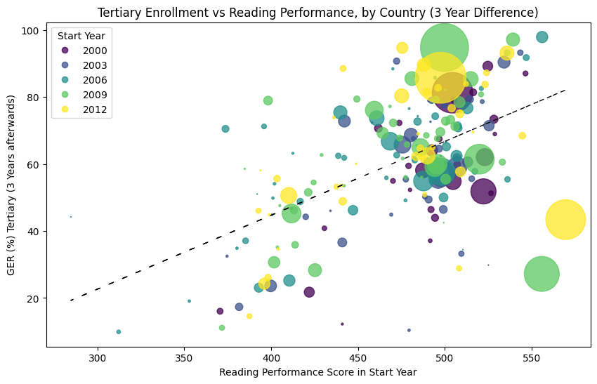

```python
# plot reading at a given year, vs enrollment 3 years later
fig, ax = plt.subplots(figsize=(10,6))
# years with reading data are: [2000, 2003, 2006, 2009, 2012, 2015]
# zip to get tuples of data
yearpairs = zip([2000, 2003, 2006, 2009, 2012], [2003, 2006, 2009, 2012, 2015])

q3_yeardiff_dflist = []

for i, years in enumerate(list(yearpairs)):
    q3df_read = q3df[q3df.Year == years[0]]
    q3df_ger = q3df[q3df.Year == years[1]]
    # merge so only get countries that appear in both
    q3df_yeardiff_merge = pd.merge(q3df_read, q3df_ger, on=["Country Code"],
                                   how="inner")
    # drop extra columns
    q3df_yeardiff_merge = q3df_yeardiff_merge[["Country Code", "Year_x",
                  "Year_y", "Reading_Performance_x", "GER_Tertiary_y", "GDP_y"]]
    q3_yeardiff_dflist.append(q3df_yeardiff_merge)

# add all rows to same df, for easier plotting
q3_yeardiff = pd.concat(q3_yeardiff_dflist)
# plot this scatter
q3_scatter = ax.scatter(x = q3_yeardiff["Reading_Performance_x"],
                        y = q3_yeardiff["GER_Tertiary_y"],
                        c = q3_yeardiff["Year_x"],
                        s = q3_yeardiff["GDP_y"] * (1.5/10**10),
                        alpha=0.75)

ax.set_xlabel("Reading Performance Score in Start Year")
ax.set_ylabel("GER (%) Tertiary (3 Years afterwards)")
ax.set_title("Tertiary Enrollment vs Reading Performance, by Country (3 Year Difference)")

ax.legend(*q3_scatter.legend_elements(), loc="upper left", title="Start Year")

# best fit line
m, b = np.polyfit(q3_yeardiff["Reading_Performance_x"], q3_yeardiff["GER_Tertiary_y"], 1)
ax.plot(q3_yeardiff["Reading_Performance_x"], m*q3_yeardiff["Reading_Performance_x"]+b, linestyle=(0,(5,10)), linewidth=1, color="black")

plt.show()
```

```python
# and the correlation coeff,
print(
    "Correlation Coefficient between Reading Score and GER Tertiary is: ",
    np.corrcoef(q3_yeardiff["Reading_Performance_x"], q3_yeardiff["GER_Tertiary_y"])[0,1]
)
```

```
Correlation Coefficient between Reading Score and GER Tertiary is:  0.5564101388954961
```

Although comparing differing years yields a slightly higher correlation coefficient, it appears the correlation is still not very significant. Perhaps there is a third marker that is affecting them both. We can check GDP to see if that may have an effect,

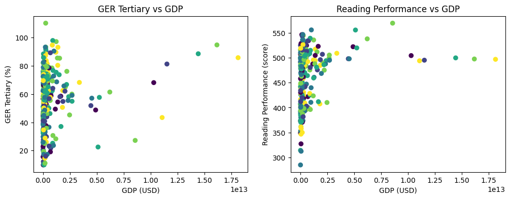

```python
# GER as a function of GDP
fig, ax = plt.subplots(1,2, figsize=(12,4))

ax[0].scatter(x = q3df.GDP,
                y = q3df.GER_Tertiary,
                c = q3df.Year)
ax[0].set_title("GER Tertiary vs GDP")
ax[0].set_xlabel("GDP (USD)")
ax[0].set_ylabel("GER Tertiary (%)")
#ax[0].set_xscale("log")

# Reading perf as a function of GDP
ax[1].scatter(x = q3df.GDP,
                y = q3df.Reading_Performance,
                c = q3df.Year)
ax[1].set_title("Reading Performance vs GDP")
ax[1].set_xlabel("GDP (USD)")
ax[1].set_ylabel("Reading Performance (score)")
#ax[1].set_xscale("log")

plt.show()
```

```python
print(
    "Correlation Coefficient between GER Tertiary and GDP is: ",
    np.corrcoef(q3df.GER_Tertiary, q3df.GDP)[0,1]
)

print(
    "Correlation Coefficient between Reading Performance and GDP is: ",
    np.corrcoef(q3df.Reading_Performance, q3df.GDP)[0,1]
)
```

```
Correlation Coefficient between GER Tertiary and GDP is:  0.16032432727749588
Correlation Coefficient between Reading Performance and GDP is:  0.20974788080980042
```

We can see there is no correlation between either of the indicators and GDP with correlation coefficients of $r=0.16$ for GER and $r=0.21$ for Reading Performance.

From the above analysis, we can see that there seems to be a small correlation between the success of students in the classroom and how many go on towards higher education. Furthermore, there seems to be no effect on this from GDP. Overall, while some of the variation (about $r^2=0.56^2\approx 0.31$) in enrollment rates can be explained by success in the classroom, this is a very complicated system and there are likely many other factors that affect this. In addition, success in the classroom is difficult to accurately represent by a single value.

### Guiding Question 4:

**What are the gender differences and trends in education?**

Firstly, we will start with finding relevant metrics to look at.

```python
get_indicators_containing_sorted("gender")
```

```
Count  | Metric
-------|---------
  7601 | Gross enrolment ratio, primary, gender parity index (GPI)
  6408 | Gross enrolment ratio, secondary, gender parity index (GPI)
  6264 | School life expectancy, primary, gender parity index (GPI)
  6223 | Gross enrolment ratio, primary and secondary, gender parity index (GPI)
  6031 | School life expectancy, primary and secondary, gender parity index (GPI)
  5505 | Gross enrolment ratio, tertiary, gender parity index (GPI)
  5359 | School life expectancy, tertiary, gender parity index (GPI)
  5350 | Gross enrolment ratio, pre-primary, gender parity index (GPI)
  5340 | School life expectancy, pre-primary, gender parity index (GPI)
  5119 | School life expectancy, secondary, gender parity index (GPI)
  5004 | Gross intake ratio to Grade 1 of primary education, gender parity index (GPI)
  4655 | Total net enrolment rate, primary, gender parity index (GPI)
  4567 | Percentage of repeaters in primary education, all grades, gender parity index (GPI)
```

[output cut: 78 more lines]

```python
get_indicators_containing_sorted("GDP")
```

```
Count  | Metric
-------|---------
  9199 | GDP (current US$)
  9196 | GDP per capita (current US$)
  8883 | GDP (constant 2010 US$)
  8880 | GDP per capita (constant 2010 US$)
  5615 | GDP, PPP (constant 2011 international $)
  5612 | GDP per capita, PPP (constant 2011 international $)
  5610 | GDP, PPP (current international $)
  5607 | GDP per capita, PPP (current international $)
  3538 | Government expenditure on education as % of GDP (%)
  1496 | Government expenditure per primary student as % of GDP per capita (%)
  1408 | Government expenditure on tertiary education as % of GDP (%)
  1367 | Government expenditure per tertiary student as % of GDP per capita (%)
  1350 | Government expenditure on primary education as % of GDP (%)
  1340 | Government expenditure on secondary education as % of GDP (%)
  1333 | Government expenditure per secondary student as % of GDP per capita (%)
  1234 | Government expenditure on pre-primary education as % of GDP (%)
  1201 | Government expenditure in secondary institutions education as % of GDP (%)
  1195 | Government expenditure in tertiary institutions as % of GDP (%)
   911 | Government expenditure per lower secondary student as % of GDP per capita (%)
   897 | Government expenditure per upper secondary student as % of GDP per capita (%)
   742 | Government expenditure on post-secondary non-tertiary education as % of GDP (%)
   613 | Government expenditure in post-secondary non-tertiary institutions as % of GDP (%)
   504 | Government expenditure per post-secondary non-tertiary student as % of GDP per capita (%)
    85 | Government expenditure on secondary and post-secondary non-tertiary vocational education as % of GDP (%)
```

```python
get_indicators_containing_sorted("Literacy")
```

```
Count  | Metric
-------|---------
  1311 | Adult literacy rate, population 15+ years, both sexes (%)
  1309 | Adult literacy rate, population 15+ years, female (%)
  1309 | Adult literacy rate, population 15+ years, male (%)
  1298 | Youth literacy rate, population 15-24 years, both sexes (%)
  1297 | Youth literacy rate, population 15-24 years, male (%)
  1297 | Youth literacy rate, population 15-24 years, gender parity index (GPI)
  1297 | Youth literacy rate, population 15-24 years, female (%)
   724 | Elderly literacy rate, population 65+ years, both sexes (%)
   691 | Literacy rate, population 25-64 years, both sexes (%)
   690 | Literacy rate, population 25-64 years, male (%)
   690 | Literacy rate, population 25-64 years, gender parity index (GPI)
   690 | Literacy rate, population 25-64 years, female (%)
   682 | Elderly literacy rate, population 65+ years, gender parity index (GPI)
```

[output cut: 34 more lines]

Below are metrics we will be using for this guiding question:

- Gross enrolment ratio, primary, gender parity index (GPI)
- Gross enrolment ratio, secondary, gender parity index (GPI)
- Gross enrolment ratio, post-secondary non-tertiary, gender parity index (GPI)
- Gross enrolment ratio, tertiary, gender parity index (GPI)
- Government expenditure on primary education as % of GDP (%)
- Government expenditure on secondary education as % of GDP (%)
- Government expenditure on post-secondary non-tertiary education as % of GDP (%)
- Government expenditure on tertiary education as % of GDP (%)
- Literacy rate, population 25-64 years, both sexes (%)

```python
q4_primary = get_data_by_name("Gross enrolment ratio, primary, gender parity index (GPI)")
q4_secondary = get_data_by_name("Gross enrolment ratio, secondary, gender parity index (GPI)")
q4_post_second = get_data_by_name("Gross enrolment ratio, post-secondary non-tertiary, gender parity index (GPI)")
q4_tertiary = get_data_by_name("Gross enrolment ratio, tertiary, gender parity index (GPI)")
q4_ge_primary = get_data_by_name("Government expenditure on primary education as % of GDP (%)")
q4_ge_secondary = get_data_by_name("Government expenditure on secondary education as % of GDP (%)")
q4_ge_post_second = get_data_by_name("Government expenditure on post-secondary non-tertiary education as % of GDP (%)")
q4_ge_tertiary = get_data_by_name("Government expenditure on tertiary education as % of GDP (%)")
q4_lr = get_data_by_name("Literacy rate, population 25-64 years, both sexes (%)")
```

We found that some data are missing from 2011 to 2015, so we will filter the data to be from 1970 to 2010.

```python
q4_primary = q4_primary[(q4_primary["Year"] >= 1970) & (q4_primary["Year"] <= 2010)]
q4_secondary = q4_secondary[(q4_secondary["Year"] >= 1970) & (q4_secondary["Year"] <= 2010)]
q4_post_second = q4_post_second[(q4_post_second["Year"] >= 1970) & (q4_post_second["Year"] <= 2010)]
q4_tertiary = q4_tertiary[(q4_tertiary["Year"] >= 1970) & (q4_tertiary["Year"] <= 2010)]
q4_ge_primary = q4_ge_primary[(q4_ge_primary["Year"] >= 1970) & (q4_ge_primary["Year"] <= 2010)]
q4_ge_secondary = q4_ge_secondary[(q4_ge_secondary["Year"] >= 1970) & (q4_ge_secondary["Year"] <= 2010)]
q4_ge_post_second = q4_ge_post_second[(q4_ge_post_second["Year"] >= 1970) & (q4_ge_post_second["Year"] <= 2010)]
q4_ge_tertiary = q4_ge_tertiary[(q4_ge_tertiary["Year"] >= 1970) & (q4_ge_tertiary["Year"] <= 2010)]
q4_lr = q4_lr[(q4_lr["Year"] >= 1970) & (q4_lr["Year"] <= 2010)]
```

Now we will visualize these data and look at them.

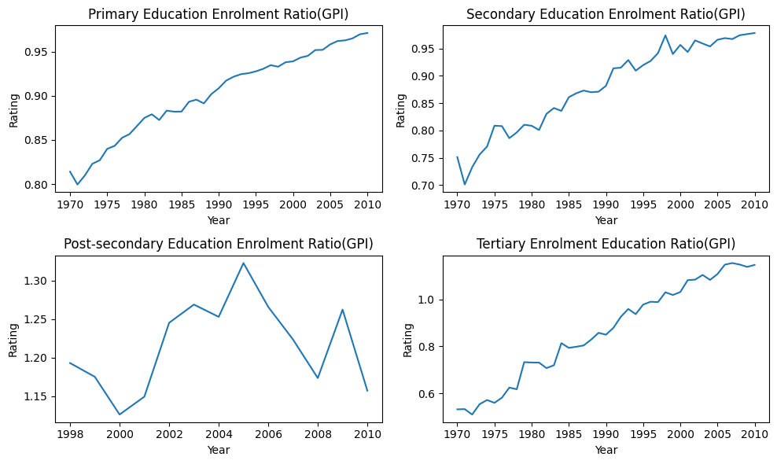

```python
q4_df1 = [q4_primary, q4_secondary,q4_post_second,q4_tertiary]
q4_plot1_titles = ["Primary Education Enrolment Ratio(GPI)", "Secondary Education Enrolment Ratio(GPI)", "Post-secondary Education Enrolment Ratio(GPI)", "Tertiary Enrolment Education Ratio(GPI)"]
fig, axs = plt.subplots(2, 2, figsize=(10, 6))
for i, ax in enumerate(axs.flat):
    #(GeeksforGeeks, Enumerate() in Python)
    q4_plot1_data = q4_df1[i].groupby("Year")["Rating"].mean().reset_index()
    ax.plot(q4_plot1_data["Year"], q4_plot1_data["Rating"])
    ax.set_title(q4_plot1_titles[i])
    ax.set_xlabel("Year")
    ax.set_ylabel("Rating")
plt.tight_layout()
plt.show()
```

GPI stands for gender parity index, it is female group value divided by male group value. When it is 1, it means equal between the two groups. If it is greater than 1, that will indicate favouring female, if it is less than 1, that means favouring male.

Looking at the primary education enrolment ratio(GPI) graph, we can see males are being favoured with a approximate value of 0.8 from 1970 to a approximate value of 0.975 in 2010. Secondary education enrolment looks similiar to the primary education enrolment with a approximate value of 0.75 at 1970 to a approximate value of 0.95 at 2010. Post-secondary education enrolment data is different from others, there is no data between 1970 and 1997, and female is being favoured from 1998 with a approximate value of 1.2 and keeping in a range of 1.1 to 1.3. Tertiary education enrolment data is similar to primary and secondary, but with more favours on male since the index value was around 0.55 in 1970. It reached a value of 1 around 2000 and kept moving up very slowly to be female favoured.

Overall, primary, secondary and terriary education were favoring male in the old days, but we have reached equality with the gender parity index value to be around 1 on education in 2010 based on the data. For higher education like post-secondary and tertiary, female is a little bit more favoured comparing to male nowadays.

We think government expenditure on education as percentage of GDP is hightly possible to correlate with education progress and thus building euqality between male and female, so we will look at it next.

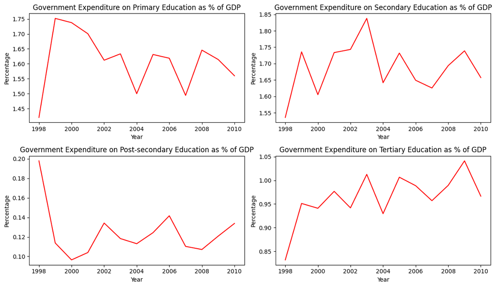

```python
q4_df2 = [q4_ge_primary, q4_ge_secondary,q4_ge_post_second,q4_ge_tertiary]
q4_plot2_titles = ["Government Expenditure on Primary Education as % of GDP", "Government Expenditure on Secondary Education as % of GDP", "Government Expenditure on Post-secondary Education as % of GDP", "Government Expenditure on Tertiary Education as % of GDP"]
fig, axs = plt.subplots(2, 2, figsize=(12, 7))
for i, ax in enumerate(axs.flat):
    #(GeeksforGeeks, Enumerate() in Python)
    q4_plot2_data = q4_df2[i].groupby("Year")["Rating"].mean().reset_index()
    ax.plot(q4_plot2_data["Year"], q4_plot2_data["Rating"],color="red")
    ax.set_title(q4_plot2_titles[i])
    ax.set_xlabel("Year")
    ax.set_ylabel("Percentage")
plt.tight_layout()
plt.show()
```

```
Correlation coefficient between Primary education enrolment GPI and government expenditure as percentage of GDP: 0.01
Correlation coefficient between Secondary education enrolment GPI and government expenditure as percentage of GDP: 0.26
Correlation coefficient between Post-Secondary education enrolment GPI and government expenditure as percentage of GDP: 0.01
Correlation coefficient between Tertiary education enrolment GPI and government expenditure as percentage of GDP: 0.32
```

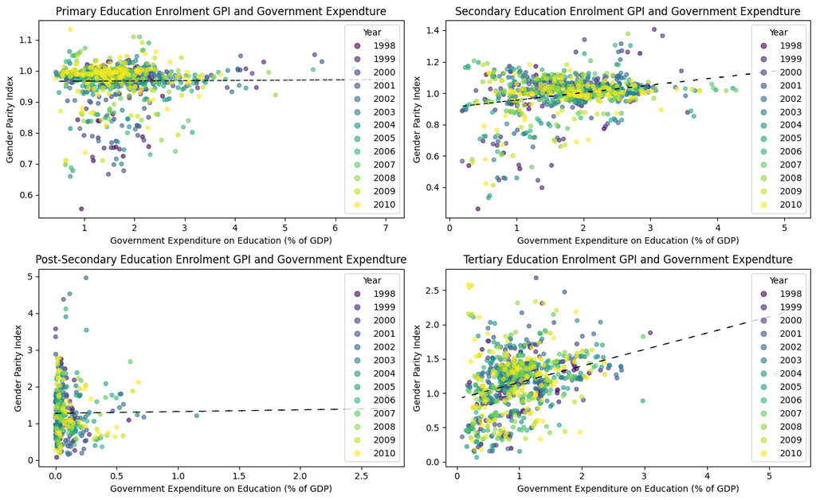

```python
q4_plot3_titles = ["Primary", "Secondary", "Post-Secondary", "Tertiary"]
fig, axs = plt.subplots(2, 2, figsize=(13, 8))
for i, ax in enumerate(axs.flat):
    #(GeeksforGeeks, Enumerate() in Python)
    q4_plot3_data = []
    q4_plot3_years = q4_df1[i]['Year'].unique()
    q4_plot3_years.sort()
    for year in q4_plot3_years:
        q4_gpi_data = q4_df1[i][q4_df1[i]['Year'] == year]
        q4_ge_data = q4_df2[i][q4_df2[i]['Year'] == year]
        q4_plot3_data_m = pd.merge(q4_gpi_data, q4_ge_data, on=['Year', 'Country Code'], suffixes=('_GPI', '_GE'))
        if not q4_plot3_data_m.empty:
            q4_plot3_data.append(q4_plot3_data_m)
    if q4_plot3_data:
        q4_plot3_data_c = pd.concat(q4_plot3_data)
        #(Pandas 2.2.3 Documentation, Pandas.Concat)
        scatter = ax.scatter(x=q4_plot3_data_c['Rating_GE'], y=q4_plot3_data_c['Rating_GPI'], c=q4_plot3_data_c['Year'], cmap='viridis', s=20, alpha=0.6)
        #(Matplotlib 3.9.2 Documentatin, Matplotlib.Axes.Axes.Scatter)
        ax.set_xlabel('Government Expenditure on Education (% of GDP)')
        ax.set_ylabel('Gender Parity Index')
        ax.set_title(f"{q4_plot3_titles[i]} Education Enrolment GPI and Government Expendture")
        m, b = np.polyfit(q4_plot3_data_c['Rating_GE'], q4_plot3_data_c['Rating_GPI'], 1)
        #(NumPy v2.0 Manual, NumPy.Polyfit)
        ax.plot(q4_plot3_data_c['Rating_GE'], m * q4_plot3_data_c['Rating_GE'] + b, linestyle=(0, (5, 10)), linewidth=1, color='black')
        handles, labels = scatter.legend_elements(prop="colors", alpha=0.6)
        legend = ax.legend(handles, labels, loc="upper right", title="Year")
        #(Matplotlib 3.9.2 Documentatin, Matplotlib.Axes.Axes.Scatter)
        q4_corcoe = np.corrcoef(q4_plot3_data_c['Rating_GE'], q4_plot3_data_c['Rating_GPI'])[0, 1]
        print(f"Correlation coefficient between {q4_plot3_titles[i]} education enrolment GPI and government expenditure as percentage of GDP: {q4_corcoe:.2f}")
plt.tight_layout()
plt.show()
```

Looking at the results and the graph, the correlations between education enrolment GPI and government expenditure as percetange of GDP are actually really weak, especially for primary and post-secondary both with the correlatio coefficient of 0.01, 0.26 for secondary, and 0.32 for tertiary. This tells us there are definitely more factors which have bigger impacts on gender equality in education. Again, there is no data from 1970 to 1998 in this dataset, it is possible to verify our logical thought of higher correlation between them with more data, but we cannot prove it at this time.

Next, we will be looking at the relationship between literacy rate for population 25-64 years and education enrolment GPI, because we believe that the more families with higher education, the less gender inequality.

```
Correlation Coefficient for Primary Education: 0.80
Correlation Coefficient for Secondary Education: 0.79
Correlation Coefficient for Post-Secondary Education: 0.50
Correlation Coefficient for Tertiary Education: 0.48
```

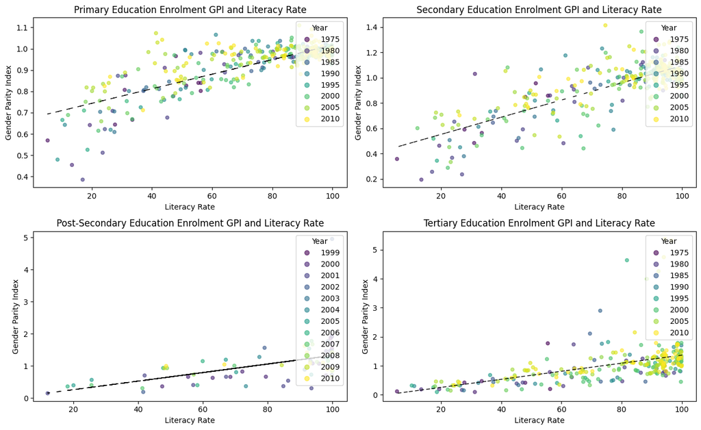

```python
fig, axs = plt.subplots(2, 2, figsize=(13, 8))
for i, ax in enumerate(axs.flat):
    #(GeeksforGeeks, Enumerate() in Python)
    q4_plot4_data = []
    q4_plot4_years = q4_df1[i]['Year'].unique()
    q4_plot4_years.sort()
    for year in q4_plot4_years:
        q4_gpi_data = q4_df1[i][q4_df1[i]['Year'] == year]
        q4_lr_data = q4_lr[q4_lr['Year'] == year]
        q4_plot4_data_m = pd.merge(q4_gpi_data, q4_lr_data, on=['Year', 'Country Code'], suffixes=('_GPI', '_LR'))
        if not q4_plot4_data_m.empty:
            q4_plot4_data.append(q4_plot4_data_m)
    if q4_plot4_data:
        q4_plot4_data_c = pd.concat(q4_plot4_data)
        #(Pandas 2.2.3 Documentation, Pandas.Concat)
        scatter = ax.scatter(x=q4_plot4_data_c['Rating_LR'], y=q4_plot4_data_c['Rating_GPI'], c=q4_plot4_data_c['Year'], cmap='viridis', s=20, alpha=0.6)
        #(Matplotlib 3.9.2 Documentatin, Matplotlib.Axes.Axes.Scatter)
        ax.set_xlabel('Literacy Rate')
        ax.set_ylabel('Gender Parity Index')
        ax.set_title(f"{q4_plot3_titles[i]} Education Enrolment GPI and Literacy Rate")
        m, b = np.polyfit(q4_plot4_data_c['Rating_LR'], q4_plot4_data_c['Rating_GPI'], 1)
        #(NumPy v2.0 Manual, NumPy.Polyfit)
        ax.plot(q4_plot4_data_c['Rating_LR'], m * q4_plot4_data_c['Rating_LR'] + b, linestyle=(0, (5, 10)), linewidth=1, color='black')
        handles, labels = scatter.legend_elements(prop="colors", alpha=0.6)
        legend = ax.legend(handles, labels, loc="upper right", title="Year")
        #(Matplotlib 3.9.2 Documentatin, Matplotlib.Axes.Axes.Scatter)
        q4_corcoe_2 = np.corrcoef(q4_plot4_data_c['Rating_LR'], q4_plot4_data_c['Rating_GPI'])[0, 1]
        print(f"Correlation Coefficient for {q4_plot3_titles[i]} Education: {q4_corcoe_2:.2f}")
plt.tight_layout()
plt.show()
```

The correlation between literacy rates and education enrolment GPI are pretty strong. We have correlation cofficient around 0.80 for primary and secondary, and around 0.5 for post-secondary and tertiary. Looking at the graph, it looks way better than the GDP expenditure on education one as well. The trends from the graph clearly show us both literacy rates and education enrolment GPI have progressed over time, which means the inequality for female in primary, secondary and terriary education has been better along with literacy rates' progress. It proves our thought on the more families with higher education, the less gender inequality.

## Discussion and Conclusion

In general, our process was to first find two metrics relating to the guiding question, and then filter down the data to a subset of only the regions and years which have data for the metrics. We could then investigate the distributions and patterns in these metrics, and see if there is any correlation between the two.

#### Guiding Question 1

For our first question, we wanted to analyze the affect that the pupil to teacher ratio has on the success of students. The metrics that we used for this analysis in addition to the pupil to teacher ratio was the percentage of students repeating a grade and the gross enrollment rate in upper secondary school. When looking at the pupil to teacher ratio and the percent of students repeating a grade we saw that there was a positive linear relationship with a correlation coefficient of ($r=0.676$). This would state that as the pupil to teacher ratio decreases, the percent of students repeating a grade would also decrease. Although this is a significant correlation coefficient it is difficult to state that these two metrics have a causation relationship because there are so many other things that could possibly be affecting them.

When looking at the relationship between the pupil to teacher ratio and the gross enrollment rate in upper secondary school we see that there is a negative relationship with a correlation coefficient of ($r=-0.811$). This is a strong negative relationship between the two metrics and it would seem that as you decrease the pupil to teacher ratio the amount of students who go on to further education increases. This would make logical sense because as the students get more one on one time with the teacher they are more likely to succeed and continue furthering their education. However, we can not say with certainty that the pupil to teacher ratio causes the gross enrollment rates to change.

#### Guiding Question 2

For our second guiding question, we wanted to see if there was a relationship between internet users in a country compared to the percentage of grade repeaters. For this question, we used the metrics of internet users per 100, which shows us the average number of people with internet access per 100 people in a given country, and percent of grade repeaters, which is the percent of students that have to repeat a grade in primary education.

Our initial analysis showed that these two variable showed a similar shape of a graph when compared side by side, suggesting early on that there may be some correlation. When comparing the two variables side by side over a time horizon, we started to notice a difference. Evidently, as the internet becomes more commonplace in many different societies, the number of mean internet users has increased over time. For the percent of grade repeaters, the opposite seems to be true. We could hypothesize many different reasons for this, however it is too big of a question to analyze for our project. Finally, we compared the two in different years, to show how the increase in internet access has impacted the number of grade repeaters. In 5 year instalments, starting in 2005, we can see that the number of internet users has risen, and the percent of grade repeaters has creeped closer and closer to the axis.

In our final graph, we showed the linear regression of our model. Our linear regression line had a negative slope of $-1.53$, meaning for every 1% increase in grade repeaters, the number of internet users per 100 drops by 1.53. Our correlation coefficient was calculated as $-0.436$, suggesting a moderate negative correlation between the two variables. We determined that this is a reasonable answer, as we can expect there to be some negative correlation between the two variables from a common sense standpoint, yet the question is too large to be explained by only these two variables.

#### Guiding Question 3

For this analysis, we wanted to look into the effect of education quality on enrollment in higher education. The specific metrics we look at were tertiary gross enrollment ratio (GER), which tells us the ratio between the number of students enrolled in post-secondary to the number of recent graduates of secondary education. We compared this to reading scores that occured a few years prior, as a measure of the quality of education received. We found only a mild positive linear correlation ($r=0.56$) between these two, indicating there is some effect on enrollment rates from the quality of education received, but the system is extremely complicated and there are likely other factors at play. This aligns roughly with what we may expect, whereby a student who does very well in school likely finds learning worthwhile and may be inspired to pursue further education. Additionally, there are lots of reasons why one may decide not to pursue education, and so it makes sense we do not see a perfect correlation, and there are other effects in play.

We also looked at correlation between each metric and the countries GDP, and found there was no worthwhile correlation, with correlation coefficients of $r=0.16$ for GER and $r=0.21$ for Reading Performance. This is surprising, because at first it seems like countries that have more money to put into education would see larger returns in quality of education and would be more likely to have a large proportion of students going on to higher education, but this does not appear to be the case.

#### Guiding Question 4

We are examining gender differences and trends through the gross enrolment ratio of the gender parity index across multiple education levels. Males were significantly favoured starting in 1970, but by 2010, enrolment rates between males and females had become almost equal based on the data. In advanced education levels, such as post-secondary and tertiary, females are even favoured more than males. We analyzed government expenditure on education as a percentage of GDP and literacy rates to find correlations with gender differences. Unfortunately, we cannot establish a correlation between government expenditure on education and gender differences based on data from 1998 to 2010, as a long period of data is missing. However, we found a strong correlation between literacy rates and gender differences: 0.80 for primary and secondary education, and 0.50 for post-secondary and tertiary education. This finding supports the idea that higher family education levels reduce gender inequality. Today, there are no significant gender differences in education, and females are slightly favoured over males in advanced education.

### Feedback and Contributions

The feedback from peers for our project presentation is valuable and constructive. We understand and find areas that lack explanations for our existing analysis and also some metrics we have not been thinking about for our further analysis. Watching other groups' presentations gave us a lot of insights into visualizing data and inspired us, that was a precious learning experience and an opportunity for progressing ourselves.

In terms of contributions, we split our four guiding questions, assigning one per member. Each member thoroughly explored their guiding question individually, and then we discussed our findings collectively for the final report. Max, Jackson, Noah, and Weiwei worked on guiding questions 1, 2, 3, and 4, respectively.

### Next Steps

If given more time, looking into more metrics could be very interesting, as well as more closely looking at the correlation that we are looking at in regards to GDP. Lots of interesting questions could be answered by this data set if we were able to more concretely find causation between metrics and not merely correlation.

There are so many metrics in this dataset that it would be interesting to investigate the guiding questions a lot more deeply. There are much more metrics that we could gain valuable insight with, in regards to our guiding questions.

Doing additional work on this data set would be very interesting because it would help shine a light on how education is affected by other factors. In Canada we are very lucky to have quite easy access to schooling and thus we sometimes can take it for granted. Its interesting to look into other places that may not have the same access to it and dive into the other problems that this causes. There are possibly many unforseen side effects of bad education systems that we would not be able to pin point without looking into the data as we are not from an enviroment like that.

I think an additional question that would be very interesting in regards to this data set would be the things that affect the gender disparities in education. Finding possible causes that affect the gender gaps in education would be very insightful and may help us determine why these disparities appear.

It would also be interesting to look at the correlation between education and happiness index ratings. It would be cool to look into these metrics and see if we see any correlation between the two because there could be many reasons as to why education may increase or decrease your happiness levels.

## References

World Bank Group. (2024). Education Statistics (World Bank EdStats; Version 3) [Dataset]. https://doi.org/10.57966/sr80-bk08

Enumerate() in Python — GeeksforGeeks. https://www.geeksforgeeks.org/enumerate-in-python/.

Pandas.Concat — Pandas 2.2.3 Documentation. https://pandas.pydata.org/docs/reference/api/pandas.concat.html.

Matplotlib.Axes.Axes.Scatter — Matplotlib 3.9.2 Documentation. https://matplotlib.org/stable/api/_as_gen/matplotlib.axes.Axes.scatter.html.

Numpy.Polyfit — NumPy v2.0 Manual. https://numpy.org/doc/2.0/reference/generated/numpy.polyfit.html.

Scatter Plots with a Legend — Matplotlib 3.9.2 Documentation. https://matplotlib.org/stable/gallery/lines_bars_and_markers/scatter_with_legend.html.

Mester, Tomi. “Linear Regression in Python Using Numpy + Polyfit (with Code Base).” Data36, 20 Feb. 2020, https://data36.com/linear-regression-in-python-numpy-polyfit/.

Matplotlib.Pyplot.Suptitle — Matplotlib 3.9.2 Documentation. https://matplotlib.org/stable/api/_as_gen/matplotlib.pyplot.suptitle.html.

How can gross school enrollment ratios be over 100 percent? – World Bank Data Help Desk. (n.d.). https://datahelpdesk.worldbank.org/knowledgebase/articles/114955-how-can-gross-school-enrollment-ratios-be-over-100